# Praktikum 1

Siti Keira Zuleyqa

2026-08-26

## Library/Packages

*Package* R yang akan digunakan pada perkuliahan Analisis Deret Waktu sesi UTS adalah: `forecast`, `graphics`, `TTR`, `TSA` . Jika *package* tersebut belum ada, silakan install terlebih dahulu.

```r
#install.packages("forecast")
#install.packages("graphics")
#install.packages("TTR")
#install.packages("TSA")
```

Jika sudah ada, silakan panggil library *package* tersebut.

```r
library("dplyr")
library("forecast")
```

```r
library("graphics")
library("TTR")
library("TSA")
```

## Impor Data

```r
library(rio) #install packages jika belum ada
```

```r
data <- import("https://raw.githubusercontent.com/kzuleyqa/MPDW/main/Pertemuan%201/Data%20K7-Air%20Quality%20Historical.xlsx")

# menampilkan 5 data pertama
head(data)
```

```
##         date     pm10    pm2_5 carbon_monoxide nitrogen_dioxide sulphur_dioxide
## 1 2024-01-01 99.57083 69.27083        1763.500         51.62500        50.08750
## 2 2024-01-02 80.86667 56.41667        1305.958         46.23750        43.60000
## 3 2024-01-03 57.44583 40.06667        1456.292         53.25417        48.95833
## 4 2024-01-04 71.47083 49.66250        2041.958         58.52500        50.65000
## 5 2024-01-05 70.52917 49.25833        2003.750         58.13333        50.77917
## 6 2024-01-06 85.63333 59.82500        1933.000         55.71667        47.29583
##       ozone aerosol_optical_depth dust  uv_index   us_aqi european_aqi
## 1 112.20833             1.0150000    0 1.7812500 172.3750     96.45833
## 2  93.37500             1.0629167    0 1.3750000 156.1250     88.58333
## 3  46.91667             0.5383333    0 0.9958333 131.5417     78.50000
## 4  41.41667             0.6716667    0 0.8291667 122.6250     75.58333
## 5  67.20833             0.5633333    0 1.9125000 142.3333     82.00000
## 6  80.41667             0.8262500    0 1.5854167 141.2083     79.20833
```

```r
# Mengambil data Anggota 3 (baris 314-469)
data3 <- data[314:469, ]

# Mengambil variabel PM10
data3 <- data3 %>%
  select(date, pm10)

# Mengubah nama kolom
colnames(data3) <- c("Tanggal", "PM10")

# Set tanggal ke format
data3$Tanggal <- as.Date(data3$Tanggal)

# Melihat data
head(data3)
```

```
##        Tanggal      PM10
## 314 2024-11-09 129.37917
## 315 2024-11-10 145.01250
## 316 2024-11-11 111.71250
## 317 2024-11-12  78.30417
## 318 2024-11-13  92.49583
## 319 2024-11-14 119.44583
```

## Eksplorasi Data

`View()` : menampilkan data dalam bentuk tabel, `str()` : menampilkan struktur data, `dim()` : menampilkan dimensi data

```r
View(data3)
str(data3)
```

```
## 'data.frame':    156 obs. of  2 variables:
##  $ Tanggal: Date, format: "2024-11-09" "2024-11-10" ...
##  $ PM10   : num  129.4 145 111.7 78.3 92.5 ...
```

```r
dim(data3)
```

```
## [1] 156   2
```

Mengubah data agar terbaca sebagai data deret waktu dengan fungsi `ts()` .

```r
data3.ts <- ts(data3$PM10)
```

Menampilkan ringkasan data

```r
summary(data3.ts)
```

```
##    Min. 1st Qu.  Median    Mean 3rd Qu.    Max.
##   19.82   39.55   55.01   57.73   67.61  145.01
```

Membuat plot data deret waktu

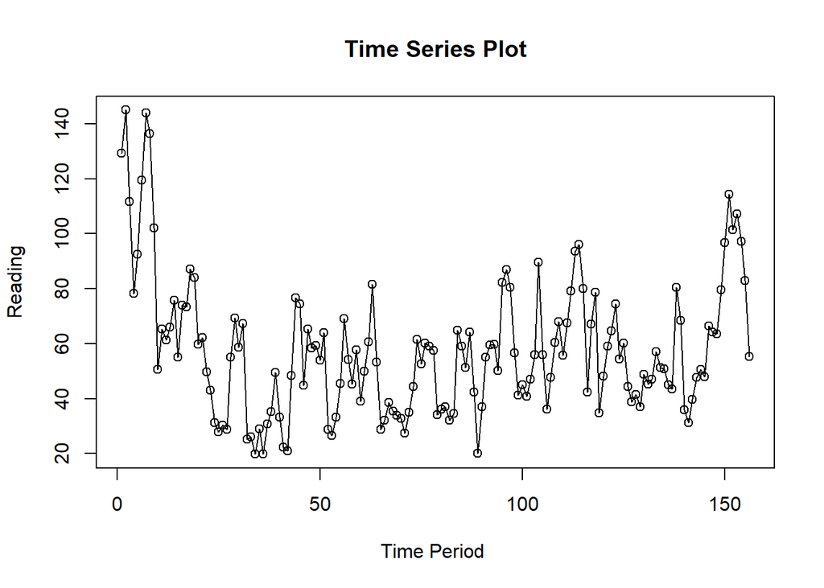

```r
ts.plot(data3.ts, xlab="Time Period ", ylab="Reading",
        main = "Time Series Plot")
points(data3.ts)
```

```r
#menyimpan plot
dev.copy(png, "plot_data3.png")
```

```r
dev.off()
```

## Single Moving Average & Double Moving Average

### Pembagian Data

Pembagian data latih dan data uji dilakukan dengan perbandingan 80% data latih dan 20% data uji.

```r
# hitung jumlah data
n <- nrow(data3)

# tentukan batas 80%
n_train <- floor(0.8 * n)

# bagi data
training_ma <- data3[1:n_train, ]
testing_ma  <- data3[(n_train+1):n, ]

# ubah ke time series
train_ma.ts <- ts(training_ma$PM10)
test_ma.ts  <- ts(testing_ma$PM10)
```

Eksplorasi data dilakukan pada keseluruhan data, data latih serta data uji menggunakan plot data deret waktu.

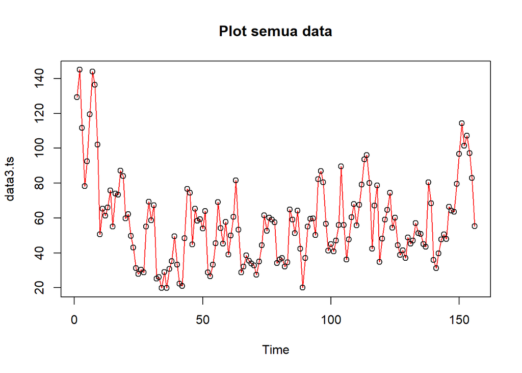

```r
#eksplorasi keseluruhan data
plot(data3.ts, col="red",main="Plot semua data")
points(data3.ts)
```

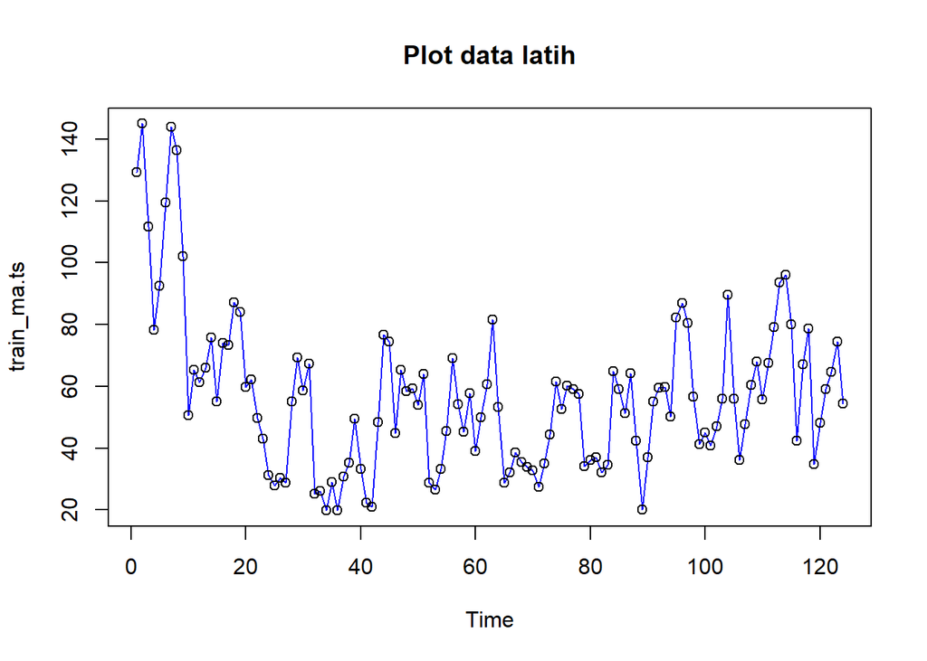

```r
#eksplorasi data latih
plot(train_ma.ts, col="blue",main="Plot data latih")
points(train_ma.ts)
```

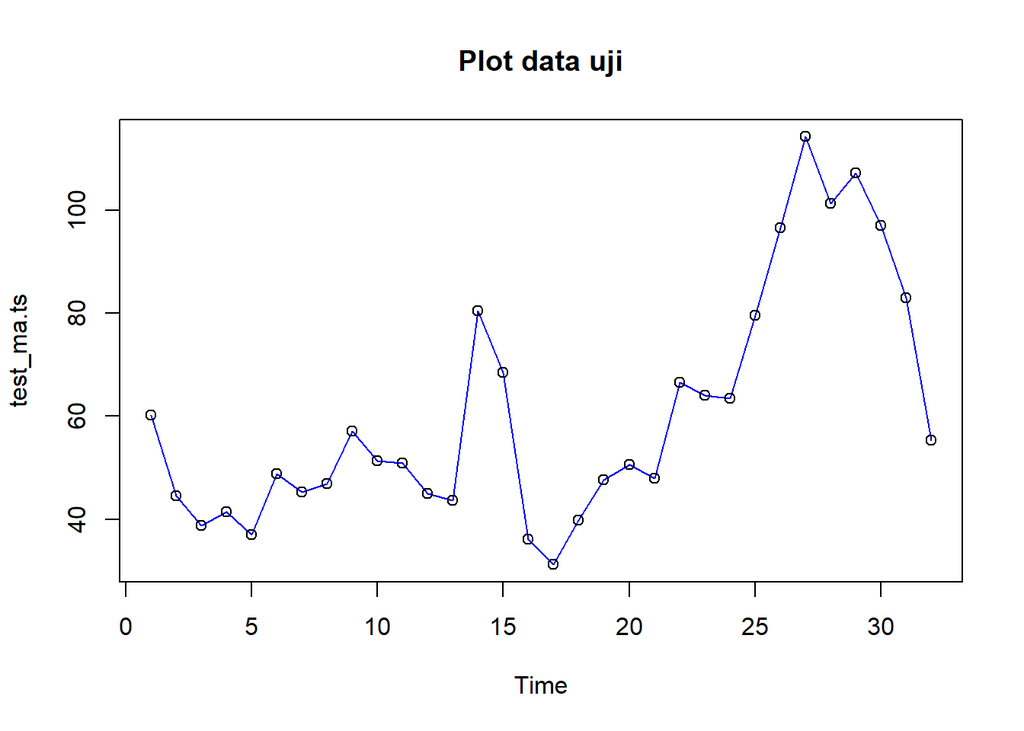

```r
#eksplorasi data uji
plot(test_ma.ts, col="blue",main="Plot data uji")
points(test_ma.ts)
```

Eksplorasi data juga dapat dilakukan menggunakan package `ggplot2` dengan terlebih dahulu memanggil library *package* `ggplot2`.

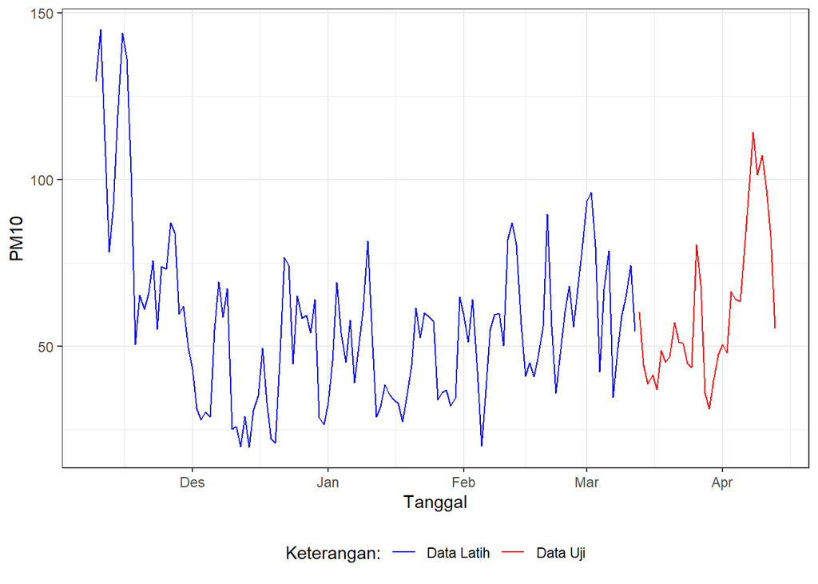

```r
library(ggplot2)
ggplot() +
  geom_line(data = training_ma, aes(x = Tanggal, y = PM10, col = "Data Latih")) +
  geom_line(data = testing_ma, aes(x = Tanggal, y = PM10, col = "Data Uji")) +
  labs(x = "Tanggal", y = "PM10", color = "Legend") +
   scale_colour_manual(name="Keterangan:", breaks = c("Data Latih", "Data Uji"),
                      values = c("blue", "red")) +
  theme_bw() + theme(legend.position = "bottom",
                     plot.caption = element_text(hjust=0.5, size=12))
```

### Single Moving Average (SMA)

Ide dasar dari Single Moving Average (SMA) adalah data suatu periode dipengaruhi oleh data periode sebelumnya. Metode pemulusan ini cocok digunakan untuk pola data stasioner atau konstan. Prinsip dasar metode pemulusan ini adalah data pemulusan pada periode ke-t merupakan rata rata dari m buah data pada periode ke-t hingga periode ke (t-m+1).

$$S_t = \frac{1}{m} \sum_{i=t-m+1}^{t} X_i$$

Data pemulusan pada periode ke-t selanjutnya digunakan sebagai nilai peramalan pada periode ke t+1.

$$F_t = S_{t-1}, F_{n,h} = S_n$$

Pemulusan menggunakan metode SMA dilakukan dengan fungsi `SMA()`. Dalam hal ini akan dilakukan pemulusan dengan parameter `m=4`.

```r
data.sma<-SMA(train_ma.ts, n=4)
data.sma
```

```
## Time Series:
## Start = 1
## End = 124
## Frequency = 1
##   [1]        NA        NA        NA 116.10208 106.88125 100.48958 108.57292
##   [8] 123.09583 125.51458 108.31354  88.64271  69.84896  60.80521  67.06667
##  [15]  64.51771  67.70104  69.51458  72.36458  79.56562  76.01458  73.24062
##  [22]  63.88229  53.67500  46.53437  37.96667  33.15000  29.58542  35.53542
##  [29]  45.89167  52.97187  62.58854  55.16667  44.34583  34.62917  25.05937
##  [36]  23.68854  24.89896  28.75312  33.87292  37.21354  35.07708  31.49583
##  [43]  31.20104  42.09271  55.10208  61.06562  65.28333  60.69687  56.93437
##  [50]  59.23854  58.95000  51.51979  43.33646  38.14167  33.51146  43.64375
##  [57]  50.52708  53.55312  56.61667  49.07396  48.05417  51.88958  57.83125
##  [64]  61.38333  56.08229  48.92500  38.17396  33.72500  34.99062  35.19375
##  [71]  32.38333  32.25000  34.86250  42.01562  48.33021  54.63333  58.30521
##  [78]  57.32708  52.68958  46.67812  41.15417  34.81771  34.93333  42.13333
##  [85]  47.66354  52.44375  59.84687  54.24271  44.52292  40.96667  38.69271
##  [92]  42.94687  52.86042  56.13437  62.91458  69.78854  74.94479  76.55937
##  [99]  66.31667  55.85937  45.97500  43.57708  47.29896  58.39687  62.18542
## [106]  59.43646  57.33542  50.04687  53.04479  57.98333  62.93229  67.61042
## [113]  73.98437  84.06979  87.19167  77.98750  71.39375  67.01354  55.71875
## [120]  57.19167  55.16458  51.69271  61.59062  63.16875
```

Data pemulusan pada periode ke-t selanjutnya digunakan sebagai nilai peramalan pada periode ke t+1 sehingga hasil peramalan 1 periode kedepan adalah sebagai berikut.

```r
data.ramal<-c(NA,data.sma)
data.ramal #forecast 1 periode ke depan
```

```
##   [1]        NA        NA        NA        NA 116.10208 106.88125 100.48958
##   [8] 108.57292 123.09583 125.51458 108.31354  88.64271  69.84896  60.80521
##  [15]  67.06667  64.51771  67.70104  69.51458  72.36458  79.56562  76.01458
##  [22]  73.24062  63.88229  53.67500  46.53437  37.96667  33.15000  29.58542
##  [29]  35.53542  45.89167  52.97187  62.58854  55.16667  44.34583  34.62917
##  [36]  25.05937  23.68854  24.89896  28.75312  33.87292  37.21354  35.07708
##  [43]  31.49583  31.20104  42.09271  55.10208  61.06562  65.28333  60.69687
##  [50]  56.93437  59.23854  58.95000  51.51979  43.33646  38.14167  33.51146
##  [57]  43.64375  50.52708  53.55312  56.61667  49.07396  48.05417  51.88958
##  [64]  57.83125  61.38333  56.08229  48.92500  38.17396  33.72500  34.99062
##  [71]  35.19375  32.38333  32.25000  34.86250  42.01562  48.33021  54.63333
##  [78]  58.30521  57.32708  52.68958  46.67812  41.15417  34.81771  34.93333
##  [85]  42.13333  47.66354  52.44375  59.84687  54.24271  44.52292  40.96667
##  [92]  38.69271  42.94687  52.86042  56.13437  62.91458  69.78854  74.94479
##  [99]  76.55937  66.31667  55.85937  45.97500  43.57708  47.29896  58.39687
## [106]  62.18542  59.43646  57.33542  50.04687  53.04479  57.98333  62.93229
## [113]  67.61042  73.98437  84.06979  87.19167  77.98750  71.39375  67.01354
## [120]  55.71875  57.19167  55.16458  51.69271  61.59062  63.16875
```

Selanjutnya dilakukan peramalan sebanyak 32 periode sesuai dengan jumlah data uji. Pada metode SMA, seluruh hasil peramalan untuk 32 periode ke depan akan memiliki nilai yang sama dengan hasil ramalan satu periode ke depan.

```r
data.gab<-cbind(
  aktual=c(data3.ts),
  pemulusan=c(data.sma,rep(NA,32)),
  ramalan=c(data.ramal,rep(data.ramal[length(data.ramal)],31)))

data.gab #forecast 32 periode ke depan
```

```
##           aktual pemulusan   ramalan
##   [1,] 129.37917        NA        NA
##   [2,] 145.01250        NA        NA
##   [3,] 111.71250        NA        NA
##   [4,]  78.30417 116.10208        NA
##   [5,]  92.49583 106.88125 116.10208
##   [6,] 119.44583 100.48958 106.88125
##   [7,] 144.04583 108.57292 100.48958
##   [8,] 136.39583 123.09583 108.57292
##   [9,] 102.17083 125.51458 123.09583
##  [10,]  50.64167 108.31354 125.51458
##  [11,]  65.36250  88.64271 108.31354
##  [12,]  61.22083  69.84896  88.64271
##  [13,]  65.99583  60.80521  69.84896
##  [14,]  75.68750  67.06667  60.80521
```

[output cut: 142 more lines]

Adapun plot data deret waktu dari hasil peramalan yang dilakukan adalah sebagai berikut.

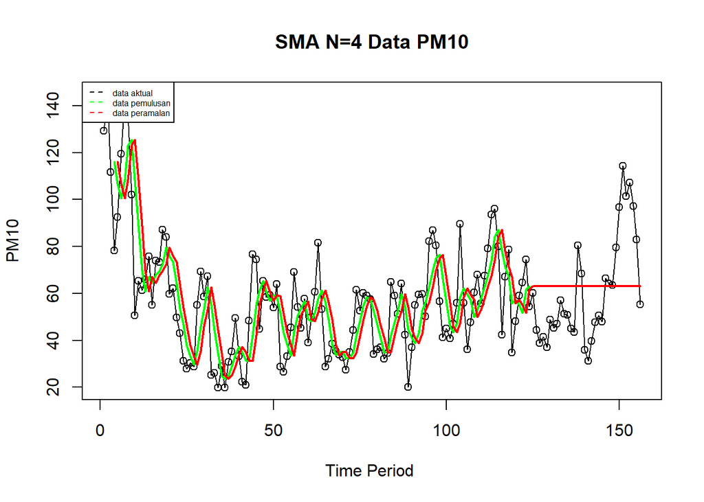

```r
ts.plot(data3.ts, xlab="Time Period ", ylab="PM10", main= "SMA N=4 Data PM10")
points(data3.ts)
lines(data.gab[,2],col="green",lwd=2)
lines(data.gab[,3],col="red",lwd=2)
legend("topleft",c("data aktual","data pemulusan","data peramalan"), lty=8, col=c("black","green","red"), cex=0.5)
```

Selanjutnya perhitungan akurasi dilakukan dengan ukuran akurasi *Sum Squares Error* (SSE), *Mean Square Error* (MSE) dan *Mean Absolute Percentage Error* (MAPE). Perhitungan akurasi dilakukan baik pada data latih maupun pada data uji.

$$SSE = \sum_{t=1}^{n} (y_t - \hat{y}_t)^2$$
$$MSE = \frac{1}{n} \sum_{t=1}^{n} (y_t - \hat{y}_t)^2$$
$$MAPE = \frac{1}{n} \sum_{t=1}^{n} \left|\frac{y_t -
\hat{y}_t}{y_t}\right| * 100$$

```r
#Menghitung nilai keakuratan data latih
error_train.sma = train_ma.ts-data.ramal[1:length(train_ma.ts)]

SSE_train.sma = sum(error_train.sma[5:length(train_ma.ts)]^2)
MSE_train.sma = mean(error_train.sma[5:length(train_ma.ts)]^2)
MAPE_train.sma = mean(abs((error_train.sma[5:length(train_ma.ts)]/train_ma.ts[5:length(train_ma.ts)])*100))

akurasi_train.sma <- matrix(c(SSE_train.sma, MSE_train.sma, MAPE_train.sma))
row.names(akurasi_train.sma)<- c("SSE", "MSE", "MAPE")
colnames(akurasi_train.sma) <- c("Akurasi m = 4")
akurasi_train.sma
```

```
##      Akurasi m = 4
## SSE    49568.28802
## MSE      413.06907
## MAPE      34.08797
```

```r
#Menghitung nilai keakuratan data uji
error_test.sma = test_ma.ts-data.gab[125:156,3]

SSE_test.sma = sum(error_test.sma^2)
MSE_test.sma = mean(error_test.sma^2)
MAPE_test.sma = mean(abs((error_test.sma/test_ma.ts*100)))

akurasi_test.sma <- matrix(c(SSE_test.sma, MSE_test.sma, MAPE_test.sma))
row.names(akurasi_test.sma)<- c("SSE", "MSE", "MAPE")
colnames(akurasi_test.sma) <- c("Akurasi m = 4")
akurasi_test.sma
```

```
##      Akurasi m = 4
## SSE    16250.65229
## MSE      507.83288
## MAPE      34.20182
```

### Double Moving Average (DMA)

Metode pemulusan Double Moving Average (DMA) pada dasarnya mirip dengan SMA. Namun demikian, metode ini lebih cocok digunakan untuk pola data trend. Proses pemulusan dengan rata rata dalam metode ini dilakukan sebanyak 2 kali.

- **Tahap I:**

$$S_{1,t} = \frac{1}{m} \sum_{i=t-m+1}^{t} X_i$$

- **Tahap II:**

$$S_{2,t} = \frac{1}{m} \sum_{i=t-m+1}^{t} S_{1,i}$$

Forecast $h$ langkah ke depan dihitung dengan:

$$F_{2,t,t+h} = A_t + B_t \,(h)$$

dengan komponen level ($A_t$) dan tren ($B_t$):

$$A_t = 2S_{1,t} - S_{2,t}
\qquad\text{dan}\qquad
B_t = \frac{2}{m-1}\,\big(S_{1,t} - S_{2,t}\big)$$

```r
dma <- SMA(data.sma, n = 4)
At <- 2*data.sma - dma
Bt <- 2/(4-1)*(data.sma - dma)
data.dma<- At+Bt
data.ramal2<- c(NA, data.dma)

t = 1:32
f = c()

for (i in t) {
  f[i] = At[length(At)] + Bt[length(Bt)]*(i)
}

data.gab2 <- cbind(aktual = c(data3.ts),
                   pemulusan1 = c(data.sma,rep(NA,32)),
                   pemulusan2 = c(dma, rep(NA,32)),
                   At = c(At, rep(NA,32)),
                   Bt = c(Bt,rep(NA,32)),
                   ramalan = c(data.ramal2, f[-1]))
data.gab2
```

```
##           aktual pemulusan1 pemulusan2        At            Bt     ramalan
##   [1,] 129.37917         NA         NA        NA            NA          NA
##   [2,] 145.01250         NA         NA        NA            NA          NA
##   [3,] 111.71250         NA         NA        NA            NA          NA
##   [4,]  78.30417  116.10208         NA        NA            NA          NA
##   [5,]  92.49583  106.88125         NA        NA            NA          NA
##   [6,] 119.44583  100.48958         NA        NA            NA          NA
##   [7,] 144.04583  108.57292  108.01146 109.13437   0.374305556          NA
##   [8,] 136.39583  123.09583  109.75990 136.43177   8.890625000 109.5086806
##   [9,] 102.17083  125.51458  114.41823 136.61094   7.397569444 145.3223958
##  [10,]  50.64167  108.31354  116.37422 100.25286  -5.373784722 144.0085069
##  [11,]  65.36250   88.64271  111.39167  65.89375 -15.165972222  94.8790799
##  [12,]  61.22083   69.84896   98.07995  41.61797 -18.820659722  50.7277778
##  [13,]  65.99583   60.80521   81.90260  39.70781 -14.064930556  22.7973090
##  [14,]  75.68750   67.06667   71.59089  62.54245  -3.016145833  25.6428819
```

[output cut: 142 more lines]

Hasil pemulusan menggunakan metode DMA divisualisasikan sebagai berikut

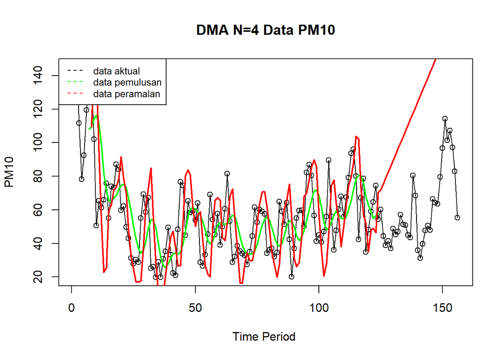

```r
ts.plot(data3.ts, xlab="Time Period ", ylab="PM10", main= "DMA N=4 Data PM10")
points(data3.ts)
lines(data.gab2[,3],col="green",lwd=2)
lines(data.gab2[,6],col="red",lwd=2)
legend("topleft",c("data aktual","data pemulusan","data peramalan"), lty=8, col=c("black","green","red"), cex=0.8)
```

Selanjutnya perhitungan akurasi dilakukan baik pada data latih maupun data uji. Perhitungan akurasi dilakukan dengan ukuran akurasi SSE, MSE dan MAPE.

```r
#Menghitung nilai keakuratan data latih
error_train.dma = train_ma.ts-data.ramal2[1:length(train_ma.ts)]

SSE_train.dma = sum(error_train.dma[8:length(train_ma.ts)]^2)
MSE_train.dma = mean(error_train.dma[8:length(train_ma.ts)]^2)
MAPE_train.dma = mean(abs((error_train.dma[8:length(train_ma.ts)]/train_ma.ts[8:length(train_ma.ts)])*100))

akurasi_train.dma <- matrix(c(SSE_train.dma, MSE_train.dma, MAPE_train.dma))
row.names(akurasi_train.dma)<- c("SSE", "MSE", "MAPE")
colnames(akurasi_train.dma) <- c("Akurasi m = 4")
akurasi_train.dma
```

```
##      Akurasi m = 4
## SSE    69953.24764
## MSE      597.89101
## MAPE      41.98088
```

```r
#Menghitung nilai keakuratan data uji
error_test.dma = test_ma.ts-data.gab2[125:156,6]
SSE_test.dma = sum(error_test.dma^2)
MSE_test.dma = mean(error_test.dma^2)
MAPE_test.dma = mean(abs((error_test.dma/test_ma.ts*100)))

akurasi_test.dma <- matrix(c(SSE_test.dma, MSE_test.dma, MAPE_test.dma))
row.names(akurasi_test.dma)<- c("SSE", "MSE", "MAPE")
colnames(akurasi_test.dma) <- c("Akurasi m = 4")
akurasi_test.dma
```

```
##      Akurasi m = 4
## SSE    156619.7892
## MSE      4894.3684
## MAPE      122.3925
```

## Single Exponential Smoothing & Double Exponential Smoothing

Metode Exponential Smoothing merupakan metode pemulusan deret waktu dengan memberikan bobot yang menurun secara eksponensial pada data historis, di mana nilai terbaru mendapat bobot lebih besar dibanding nilai yang lebih lama. Metode ini menggunakan satu atau lebih parameter pemulusan yang secara langsung menentukan besar kecilnya bobot setiap pengamatan. Pemilihan parameter yang tepat akan sangat berpengaruh terhadap hasil ramalan. Secara umum, Exponential Smoothing dibedakan menjadi dua jenis, yaitu model tunggal (single) yang digunakan untuk data tanpa tren maupun musiman, serta model ganda (double) yang mampu menangkap adanya tren pada data.

### Pembagian Data

Pembagian data latih dan data uji dilakukan dengan perbandingan 80% data latih dan 20% data uji.

```r
# jumlah baris data
n <- nrow(data3)

# hitung batas 80%
n_train <- floor(0.8 * n)

# bagi data
training <- data3[1:n_train, ]
testing  <- data3[(n_train+1):n, ]

# ubah ke time series
train.ts <- ts(training$PM10)
test.ts  <- ts(testing$PM10)
```

### Eksplorasi

Eksplorasi dilakukan dengan membuat plot data deret waktu untuk keseluruhan data, data latih, dan data uji.

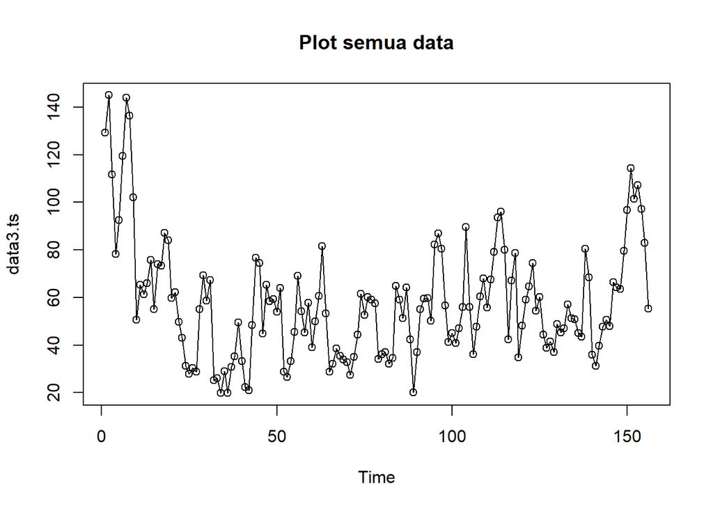

```r
#eksplorasi data
plot(data3.ts, col="black",main="Plot semua data")
points(data3.ts)
```

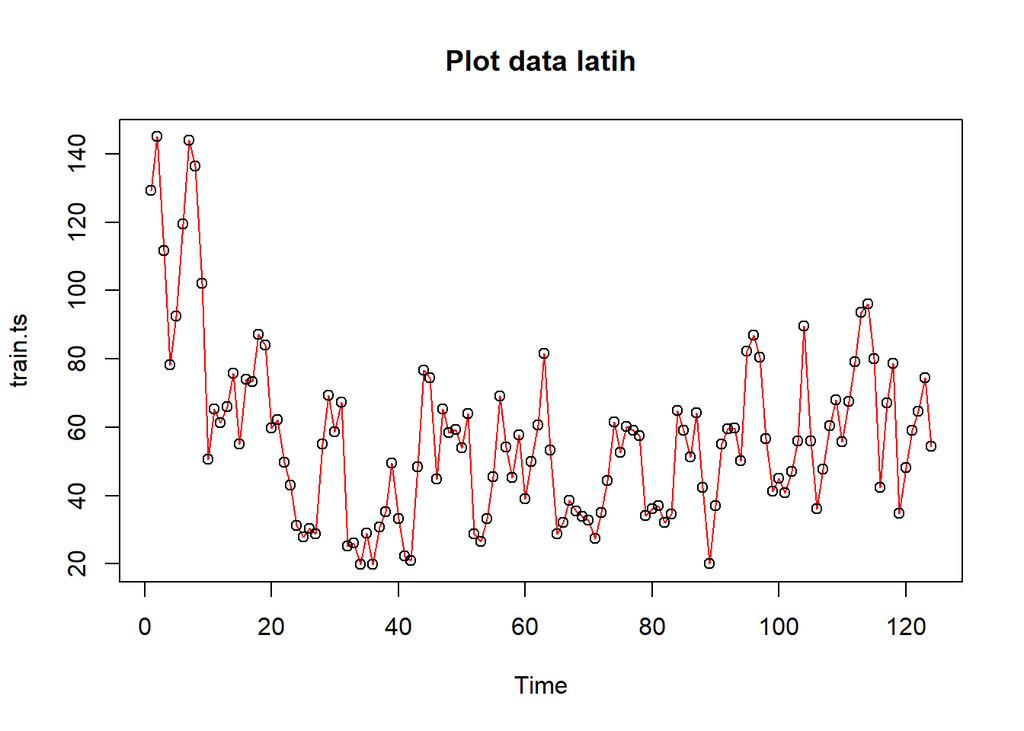

```r
plot(train.ts, col="red",main="Plot data latih")
points(train.ts)
```

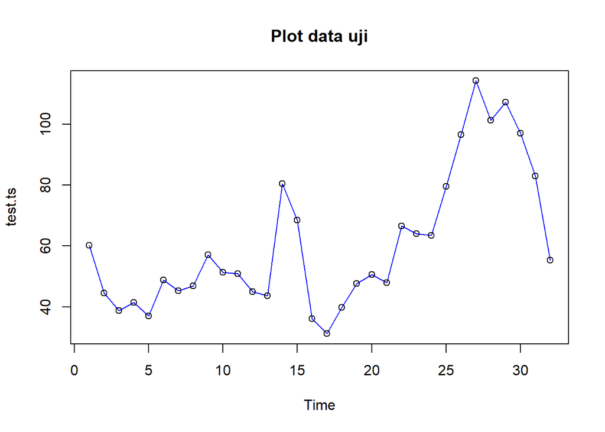

```r
plot(test.ts, col="blue",main="Plot data uji")
points(test.ts)
```

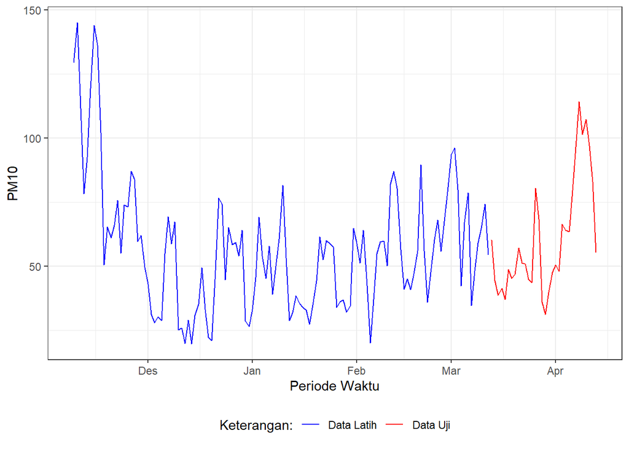

```r
#Eksplorasi dengan GGPLOT
library(ggplot2)
ggplot() +
  geom_line(data = training, aes(x = Tanggal, y = PM10, col = "Data Latih")) +
  geom_line(data = testing, aes(x = Tanggal, y = PM10, col = "Data Uji")) +
  labs(x = "Periode Waktu", y = "PM10", color = "Legend") +
  scale_colour_manual(name="Keterangan:", breaks = c("Data Latih", "Data Uji"),
                      values = c("blue", "red")) +
  theme_bw() + theme(legend.position = "bottom",
                     plot.caption = element_text(hjust=0.5, size=12))
```

## Single Exponential Smoothing

Single Exponential Smoothing (SES) adalah metode peramalan deret waktu yang dikembangkan untuk mengatasi kelemahan Moving Average. Jika pada Moving Average setiap data periode sebelumnya dianggap memiliki bobot yang sama, maka SES memberikan bobot yang semakin mengecil secara eksponensial terhadap data lama, sehingga data terbaru diberi bobot lebih besar.

Single Exponential Smoothing merupakan metode pemulusan yang tepat digunakan untuk data dengan pola stasioner atau konstan.

Nilai pemulusan pada periode ke-t didapat dari persamaan:

$$\tilde{y}_T=\lambda
y_t+(1-\lambda)\tilde{y}_{T-1}$$

Nilai parameter $\lambda$ adalah nilai antara 0 dan 1.

Nilai pemulusan periode ke-t bertindak sebagai nilai ramalan pada periode ke-$(T+\tau)$.

$$\tilde{y}_{T+\tau}(T)=\tilde{y}_T$$

Pemulusan dengan metode SES dapat dilakukan dengan dua fungsi dari *packages* berbeda, yaitu (1) fungsi `ses()` dari *packages* `forecast` dan (2) fungsi `HoltWinters` dari *packages* `stats` .

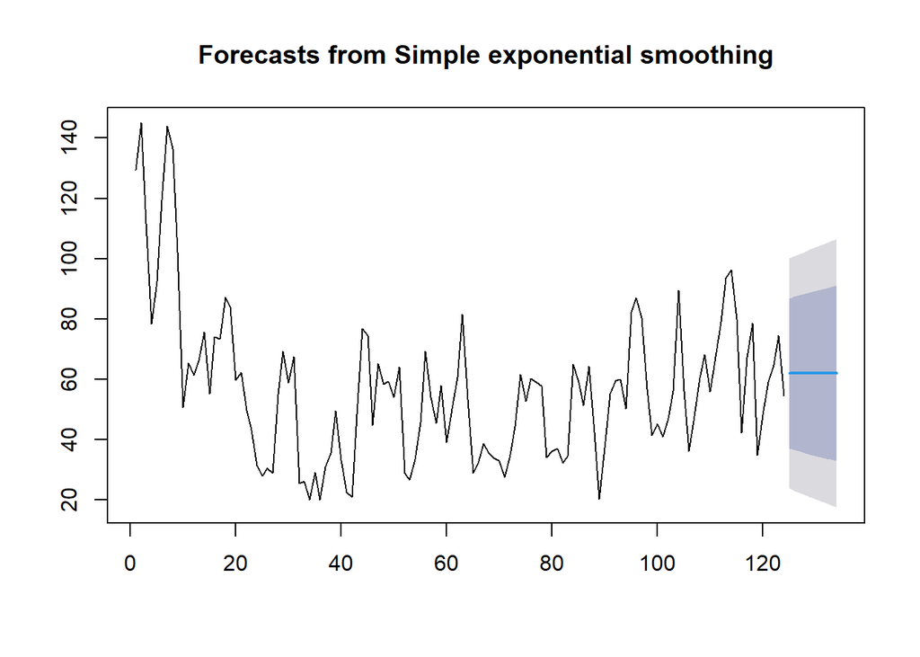

```r
#Cara 1 (fungsi ses)
ses.1 <- ses(train.ts, h = 10, alpha = 0.2)
plot(ses.1)
```

```r
ses.1
```

```
##     Point Forecast    Lo 80    Hi 80    Lo 95    Hi 95
## 125       61.87683 36.92717 86.82649 23.71961 100.0340
## 126       61.87683 36.43306 87.32059 22.96395 100.7897
## 127       61.87683 35.94838 87.80528 22.22269 101.5310
## 128       61.87683 35.47259 88.28107 21.49503 102.2586
## 129       61.87683 35.00522 88.74843 20.78025 102.9734
## 130       61.87683 34.54584 89.20781 20.07769 103.6760
## 131       61.87683 34.09406 89.65959 19.38675 104.3669
## 132       61.87683 33.64951 90.10415 18.70687 105.0468
## 133       61.87683 33.21185 90.54181 18.03753 105.7161
## 134       61.87683 32.78077 90.97288 17.37825 106.3754
```

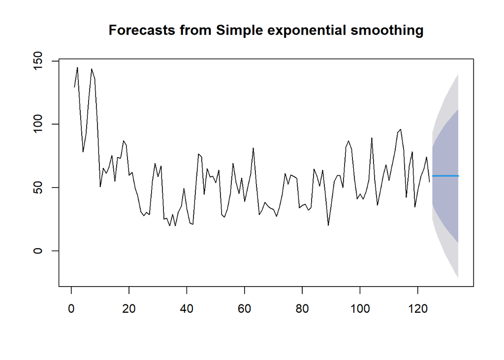

```r
ses.2<- ses(train.ts, h = 10, alpha = 0.7)
plot(ses.2)
```

```r
ses.2
```

```
##     Point Forecast     Lo 80     Hi 80       Lo 95     Hi 95
## 125       59.33902 36.655908  82.02213  24.6481951  94.02984
## 126       59.33902 31.650754  87.02728  16.9934721 101.68456
## 127       59.33902 27.421053  91.25698  10.5247032 108.15333
## 128       59.33902 23.689713  94.98832   4.8181101 113.85993
## 129       59.33902 20.313520  98.36452  -0.3453306 119.02337
## 130       59.33902 17.207011 101.47103  -5.0963259 123.77436
## 131       59.33902 14.314330 104.36371  -9.5202995 128.19834
## 132       59.33902 11.596595 107.08144 -13.6767178 132.35475
## 133       59.33902  9.025446 109.65259 -17.6089498 136.28699
## 134       59.33902  6.579450 112.09859 -21.3497781 140.02781
```

Pada fungsi `ses()` , terdapat beberapa argumen yang umum digunakan, yaitu

- `y` : nilai data deret waktu
- `alpha` : parameter pemulusan utama (0–1), mengatur bobot data terbaru vs data lama.
- `beta` : parameter pemulusan tren.
- `gamma` : parameter pemulusan musiman.
- `h` : jumlah periode ke depan yang ingin diramalkan (forecast horizon).

  Kasus di atas merupakan contoh inisialisasi nilai parameter $\lambda$ dengan nilai `alpha` 0,2 dan 0,7 dan banyak periode data yang akan diramalkan adalah sebanyak 10 periode.

Untuk mendapatkan gambar hasil pemulusan pada data latih dengan fungsi `ses()` , perlu digunakan fungsi `autoplot()` dan `autolayer()` dari *library packages* `ggplot2` .

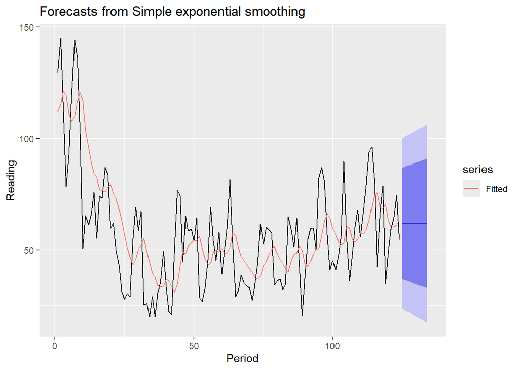

```r
autoplot(ses.1) +
  autolayer(fitted(ses.1), series="Fitted") +
  ylab("Reading") + xlab("Period")
```

Selanjutnya akan digunakan fungsi `HoltWinters()` dengan nilai inisialisasi parameter dan panjang periode peramalan yang sama dengan fungsi `ses()` .

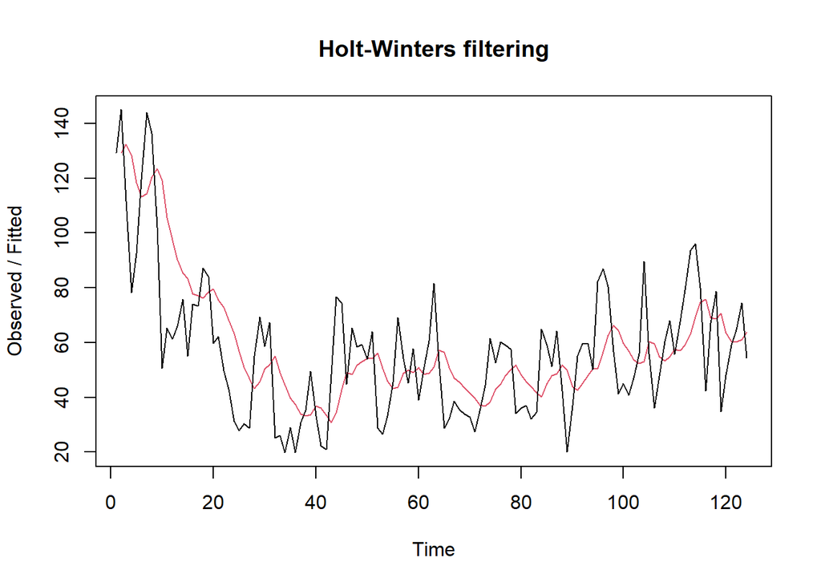

```r
#Cara 2 (fungsi Holtwinter)
ses1<- HoltWinters(train.ts, gamma = FALSE, beta = FALSE, alpha = 0.2)
plot(ses1)
```

```r
#ramalan
ramalan1<- forecast(ses1, h=10)
ramalan1
```

```
##     Point Forecast    Lo 80    Hi 80    Lo 95    Hi 95
## 125       61.87683 36.94704 86.80662 23.75000 100.0037
## 126       61.87683 36.45333 87.30032 22.99494 100.7587
## 127       61.87683 35.96903 87.78462 22.25427 101.4994
## 128       61.87683 35.49362 88.26004 21.52719 102.2265
## 129       61.87683 35.02662 88.72703 20.81298 102.9407
## 130       61.87683 34.56761 89.18604 20.11098 103.6427
## 131       61.87683 34.11619 89.63747 19.42059 104.3331
## 132       61.87683 33.67199 90.08166 18.74125 105.0124
## 133       61.87683 33.23468 90.51898 18.07244 105.6812
## 134       61.87683 32.80395 90.94971 17.41369 106.3400
```

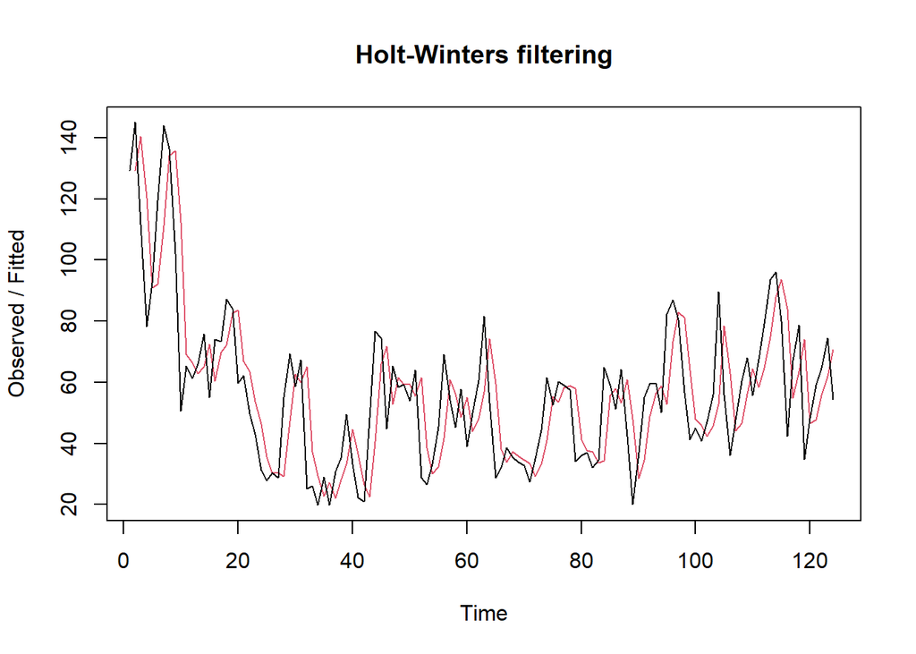

```r
ses2<- HoltWinters(train.ts, gamma = FALSE, beta = FALSE, alpha = 0.7)
plot(ses2)
```

```r
#ramalan
ramalan2<- forecast(ses2, h=10)
ramalan2
```

```
##     Point Forecast     Lo 80     Hi 80      Lo 95     Hi 95
## 125       59.33902 36.679758  81.99828  24.684670  93.99337
## 126       59.33902 31.679866  86.99817  17.037995 101.64004
## 127       59.33902 27.454613  91.22342  10.576028 108.10201
## 128       59.33902 23.727195  94.95084   4.875435 113.80260
## 129       59.33902 20.354553  98.32348  -0.282577 118.96061
## 130       59.33902 17.251310 101.42673  -5.028577 123.70661
## 131       59.33902 14.361671 104.31637  -9.447899 128.12594
## 132       59.33902 11.646792 107.03124 -13.599947 132.27798
## 133       59.33902  9.078347 109.59969 -17.528045 136.20608
## 134       59.33902  6.634923 112.04311 -21.264940 139.94298
```

Fungsi `HoltWinters` memiliki argumen yang sama dengan fungsi `ses()` . Argumen-argumen kedua fungsi dapat dilihat lebih lanjut dengan `?ses()` atau `?HoltWinters` .

Nilai parameter $\alpha$ dari kedua fungsi dapat dioptimalkan menyesuaikan dari *error*-nya paling minimumnya. Caranya adalah dengan membuat parameter $\alpha =$ `NULL` .

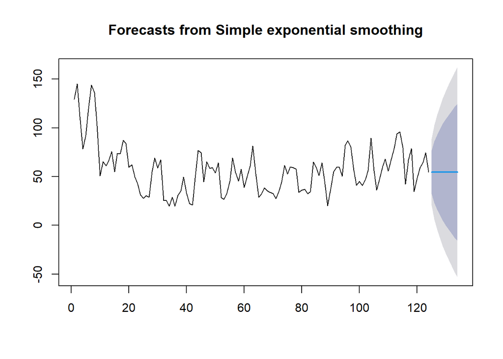

```r
#SES
ses.opt <- ses(train.ts, h = 10, alpha = NULL)
plot(ses.opt)
```

```r
ses.opt
```

```
##     Point Forecast        Lo 80     Hi 80      Lo 95     Hi 95
## 125       54.48976  32.21250096  76.76702  20.419633  88.55989
## 126       54.48976  22.98674963  85.99277   6.310064 102.66946
## 127       54.48976  15.90734104  93.07218  -4.516958 113.49648
## 128       54.48976   9.93904236  99.04048 -13.644683 122.62420
## 129       54.48976   4.68082675 104.29869 -21.686430 130.66595
## 130       54.48976  -0.07298572 109.05250 -28.956758 137.93628
## 131       54.48976  -4.44458150 113.42410 -35.642537 144.62206
## 132       54.48976  -8.51357322 117.49309 -41.865523 150.84504
## 133       54.48976 -12.33526065 121.31478 -47.710290 156.68981
## 134       54.48976 -15.94990760 124.92943 -53.238415 162.21793
```

```r
#Lamda Optimum Holt Winter
HWopt<- HoltWinters(train.ts, gamma = FALSE, beta = FALSE,alpha = NULL)
HWopt
```

```
## Holt-Winters exponential smoothing without trend and without seasonal component.
##
## Call:
## HoltWinters(x = train.ts, alpha = NULL, beta = FALSE, gamma = FALSE)
##
## Smoothing parameters:
##  alpha: 0.9999339
##  beta : FALSE
##  gamma: FALSE
##
## Coefficients:
##       [,1]
## a 54.48881
```

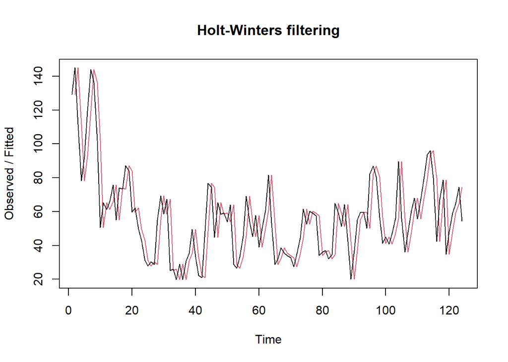

```r
plot(HWopt)
```

```r
#ramalan
ramalanopt<- forecast(HWopt, h=10)
ramalanopt
```

```
##     Point Forecast        Lo 80     Hi 80      Lo 95     Hi 95
## 125       54.48881  32.22533849  76.75229  20.439767  88.53786
## 126       54.48881  23.00454585  85.97308   6.337781 102.63985
## 127       54.48881  15.92904302  93.04858  -4.483266 113.46089
## 128       54.48881   9.96407106  99.01356 -13.605904 122.58353
## 129       54.48881   4.70880266 104.26882 -21.643143 130.62077
## 130       54.48881  -0.04233603 109.01996 -28.909383 137.88701
## 131       54.48881  -4.41146714 113.38909 -35.591392 144.56902
## 132       54.48881  -8.47816078 117.45579 -41.810864 150.78849
## 133       54.48881 -12.29768694 121.27531 -47.652325 156.62995
## 134       54.48881 -15.91028757 124.88791 -53.177321 162.15495
```

Setelah dilakukan peramalan, akan dilakukan perhitungan keakuratan hasil peramalan. Perhitungan akurasi ini dilakukan baik pada data latih dan data uji.

#### Akurasi Data Latih

Perhitungan akurasi data dapat dilakukan dengan cara langsung maupun manual. Secara langsung, nilai akurasi dapat diambil dari objek yang tersimpan pada hasil SES, yaitu *sum of squared errors* (SSE). Nilai akurasi lain dapat dihitung pula dari nilai SSE tersebut.

```r
#Keakuratan Metode
#Pada data training

# SES dengan alpha = 0.2
SSE1<-ses1$SSE
MSE1<-ses1$SSE/length(train.ts)
RMSE1<-sqrt(MSE1)

akurasi1 <- matrix(c(SSE1,MSE1,RMSE1))
row.names(akurasi1)<- c("SSE", "MSE", "RMSE")
colnames(akurasi1) <- c("Akurasi lamda=0.2")
akurasi1
```

```
##      Akurasi lamda=0.2
## SSE        47092.41349
## MSE          379.77753
## RMSE          19.48788
```

```r
# SES dengan alpha = 0.7
SSE2<-ses2$SSE
MSE2<-ses2$SSE/length(train.ts)
RMSE2<-sqrt(MSE2)

akurasi2 <- matrix(c(SSE2,MSE2,RMSE2))
row.names(akurasi2)<- c("SSE", "MSE", "RMSE")
colnames(akurasi2) <- c("Akurasi lamda=0.7")
akurasi2
```

```
##      Akurasi lamda=0.7
## SSE        38221.25647
## MSE          308.23594
## RMSE          17.55665
```

```r
#Cara Manual
# Alpha = 0.2
fitted1<-ramalan1$fitted
sisaan1<-ramalan1$residuals
head(sisaan1)
```

```
## Time Series:
## Start = 1
## End = 6
## Frequency = 1
## [1]         NA  15.633333 -20.793333 -50.043000 -25.842733   6.275813
```

```r
resid1<-training$PM10-ramalan1$fitted
head(resid1)
```

```
## Time Series:
## Start = 1
## End = 6
## Frequency = 1
## [1]         NA  15.633333 -20.793333 -50.043000 -25.842733   6.275813
```

```r
SSE.1=sum(sisaan1[2:length(train.ts)]^2)
SSE.1
```

```
## [1] 47092.41
```

```r
MSE.1 = SSE.1/length(train.ts)
MSE.1
```

```
## [1] 379.7775
```

```r
MAPE.1 = sum(abs(sisaan1[2:length(train.ts)]/train.ts[2:length(train.ts)])*
               100)/length(train.ts)
MAPE.1
```

```
## [1] 33.52124
```

```r
akurasi.1 <- matrix(c(SSE.1,MSE.1,MAPE.1))
row.names(akurasi.1)<- c("SSE", "MSE", "MAPE")
colnames(akurasi.1) <- c("Akurasi lamda=0.2")
akurasi.1
```

```
##      Akurasi lamda=0.2
## SSE        47092.41349
## MSE          379.77753
## MAPE          33.52124
```

```r
# Alpha = 0.7
fitted2<-ramalan2$fitted
sisaan2<-ramalan2$residuals
head(sisaan2)
```

```
## Time Series:
## Start = 1
## End = 6
## Frequency = 1
## [1]         NA  15.633333 -28.610000 -41.991333   1.594267  27.428280
```

```r
resid2<-training$PM10-ramalan2$fitted
head(resid2)
```

```
## Time Series:
## Start = 1
## End = 6
## Frequency = 1
## [1]         NA  15.633333 -28.610000 -41.991333   1.594267  27.428280
```

```r
SSE.2=sum(sisaan2[2:length(train.ts)]^2)
SSE.2
```

```
## [1] 38221.26
```

```r
MSE.2 = SSE.2/length(train.ts)
MSE.2
```

```
## [1] 308.2359
```

```r
MAPE.2 = sum(abs(sisaan2[2:length(train.ts)]/train.ts[2:length(train.ts)])*
               100)/length(train.ts)
MAPE.2
```

```
## [1] 27.54265
```

```r
akurasi.2 <- matrix(c(SSE.2,MSE.2,MAPE.2))
row.names(akurasi.2)<- c("SSE", "MSE", "MAPE")
colnames(akurasi.2) <- c("Akurasi lamda=0.7")
akurasi.2
```

```
##      Akurasi lamda=0.7
## SSE        38221.25647
## MSE          308.23594
## MAPE          27.54265
```

#### Akurasi Data Uji

Akurasi data uji dapat dihitung dengan cara yang hampir sama dengan perhitungan akurasi data latih.

```r
# jumlah observasi uji
n_test <- nrow(testing)

# error (ramalan - aktual), samakan panjang dan tipe numeric
e1   <- as.numeric(ramalan1$mean)[1:n_test] - as.numeric(testing$PM10)
e2   <- as.numeric(ramalan2$mean)[1:n_test] - as.numeric(testing$PM10)
eopt <- as.numeric(ramalanopt$mean)[1:n_test] - as.numeric(testing$PM10)

# SSE / MSE / RMSE untuk masing-masing model (abaikan NA)
SSEtesting1  <- sum(e1^2,  na.rm = TRUE)
MSEtesting1  <- mean(e1^2, na.rm = TRUE)
RMSEtesting1 <- sqrt(MSEtesting1)

SSEtesting2  <- sum(e2^2,  na.rm = TRUE)
MSEtesting2  <- mean(e2^2, na.rm = TRUE)
RMSEtesting2 <- sqrt(MSEtesting2)

SSEtestingopt  <- sum(eopt^2,  na.rm = TRUE)
MSEtestingopt  <- mean(eopt^2, na.rm = TRUE)
RMSEtestingopt <- sqrt(MSEtestingopt)

# Tabel ringkas
akurasitesting_SSE <- matrix(c(SSEtesting1, SSEtesting2, SSEtestingopt),
                             nrow = 3,
                             dimnames = list(c("SSE1","SSE2","SSEopt"), "Nilai"))
akurasitesting_MSE <- matrix(c(MSEtesting1, MSEtesting2, MSEtestingopt),
                             nrow = 3,
                             dimnames = list(c("MSE1","MSE2","MSEopt"), "Nilai"))
akurasitesting_RMSE <- matrix(c(RMSEtesting1, RMSEtesting2, RMSEtestingopt),
                              nrow = 3,
                              dimnames = list(c("RMSE1","RMSE2","RMSEopt"), "Nilai"))

akurasitesting_SSE
```

```
##           Nilai
## SSE1   2683.475
## SSE2   1999.514
## SSEopt 1050.676
```

```r
akurasitesting_MSE
```

```
##           Nilai
## MSE1   268.3475
## MSE2   199.9514
## MSEopt 105.0676
```

```r
akurasitesting_RMSE
```

```
##            Nilai
## RMSE1   16.38131
## RMSE2   14.14042
## RMSEopt 10.25025
```

Selain dengan cara di atas, perhitungan nilai akurasi dapat menggunakan fungsi `accuracy()` dari *package* `forecast` . Penggunaannya yaitu dengan menuliskan `accuracy(hasil ramalan, kondisi aktual)` . Contohnya adalah sebagai berikut.

```r
length(ramalan1)
```

```
## [1] 10
```

```r
length(ramalan2)
```

```
## [1] 10
```

```r
length(ramalanopt)
```

```
## [1] 10
```

```r
length(testing$PM10)
```

```
## [1] 32
```

```r
accuracy(ramalan1, testing$PM10[1:10])
```

```
##                      ME     RMSE      MAE       MPE     MAPE     MASE      ACF1
## Training set  -2.743998 19.56694 15.90160 -15.42059 33.79377 1.169364 0.5251435
## Test set     -14.744327 16.38131 14.74433 -34.24504 34.24504 1.084261        NA
```

```r
accuracy(ramalan2, testing$PM10[1:10])
```

```
##                       ME     RMSE      MAE        MPE     MAPE      MASE
## Training set  -0.8134744 17.62787 13.54427  -8.403885 27.76658 0.9960115
## Test set     -12.2065182 14.14042 12.39205 -28.739135 29.04698 0.9112799
##                   ACF1
## Training set 0.2064299
## Test set            NA
```

```r
accuracy(ramalanopt, testing$PM10[1:10])
```

```
##                      ME     RMSE       MAE        MPE     MAPE      MASE
## Training set -0.6089049 17.31223 13.598392  -6.391705 27.34666 0.9999914
## Test set     -7.3563136 10.25025  9.044955 -18.216360 21.06648 0.6651431
##                      ACF1
## Training set -0.001080255
## Test set               NA
```

## *Double Exponential Smoothing* (DES)

Metode pemulusan *Double Exponential Smoothing* (DES) digunakan untuk data yang memiliki pola tren. Metode DES adalah metode semacam SES, hanya saja dilakukan dua kali, yaitu pertama untuk tahapan ‘level’ dan kedua untuk tahapan ‘tren’. Pemulusan menggunakan metode ini akan menghasilkan peramalan tidak konstan untuk periode berikutnya.

Pemulusan dengan metode DES kali ini akan menggunakan fungsi `HoltWinters()` . Jika sebelumnya nilai argumen `beta` dibuat `FALSE` , kali ini argumen tersebut akan diinisialisasi bersamaan dengan nilai `alpha` .

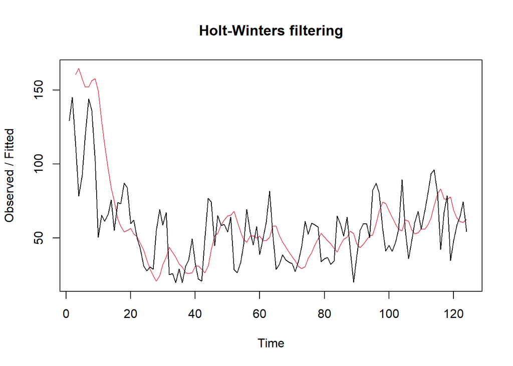

```r
#Lamda=0.2 dan gamma=0.2
des.1<- HoltWinters(train.ts, gamma = FALSE, beta = 0.2, alpha = 0.2)
plot(des.1)
```

```r
#ramalan
ramalandes1<- forecast(des.1, h=10)
ramalandes1
```

```
##     Point Forecast      Lo 80     Hi 80       Lo 95    Hi 95
## 125       59.98987 28.4032360  91.57651  11.6822815 108.2975
## 126       58.95530 26.4717041  91.43889   9.2759278 108.6347
## 127       57.92073 24.2546483  91.58680   6.4329030 109.4085
## 128       56.88615 21.7354659  92.03684   3.1278155 110.6445
## 129       55.85158 18.9073697  92.79579  -0.6497149 112.3529
## 130       54.81701 15.7720445  93.86197  -4.8971115 114.5311
## 131       53.78244 12.3376907  95.22718  -9.6018329 117.1667
## 132       52.74787  8.6169159  96.87881 -14.7445975 120.2403
## 133       51.71329  4.6248340  98.80175 -20.3022903 123.7289
## 134       50.67872  0.3775621 100.97988 -26.2502626 127.6077
```

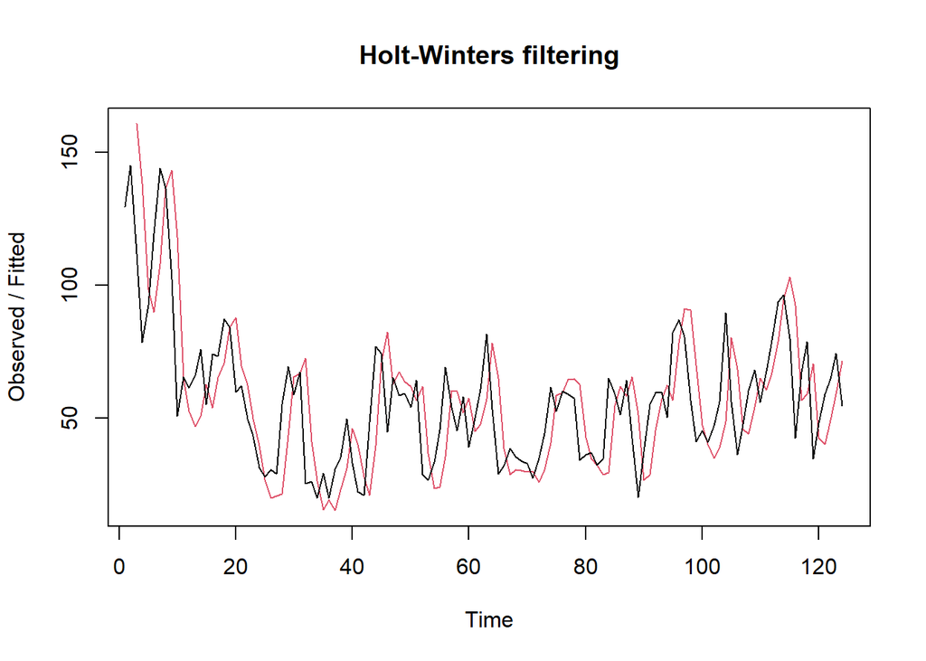

```r
#Lamda=0.6 dan gamma=0.3
des.2<- HoltWinters(train.ts, gamma = FALSE, beta = 0.3, alpha = 0.6)
plot(des.2)
```

```r
#ramalan
ramalandes2<- forecast(des.2, h=10)
ramalandes2
```

```
##     Point Forecast       Lo 80     Hi 80       Lo 95    Hi 95
## 125       61.49467  34.7120126  88.27734   20.534128 102.4552
## 126       61.69839  27.7318942  95.66489    9.751117 113.6457
## 127       61.90211  19.3016779 104.50254   -3.249628 127.0538
## 128       62.10583   9.6938616 114.51779  -18.051356 142.2630
## 129       62.30954  -0.9111542 125.53024  -34.378170 158.9973
## 130       62.51326 -12.3920545 137.41858  -52.044533 177.0711
## 131       62.71698 -24.6634812 150.09744  -70.919902 196.3539
## 132       62.92070 -37.6623729 163.50376  -90.907833 216.7492
## 133       63.12441 -51.3400571 177.58888 -111.933887 238.1827
## 134       63.32813 -65.6575673 192.31383 -133.938471 260.5947
```

Selanjutnya jika ingin membandingkan plot data latih dan data uji adalah sebagai berikut.

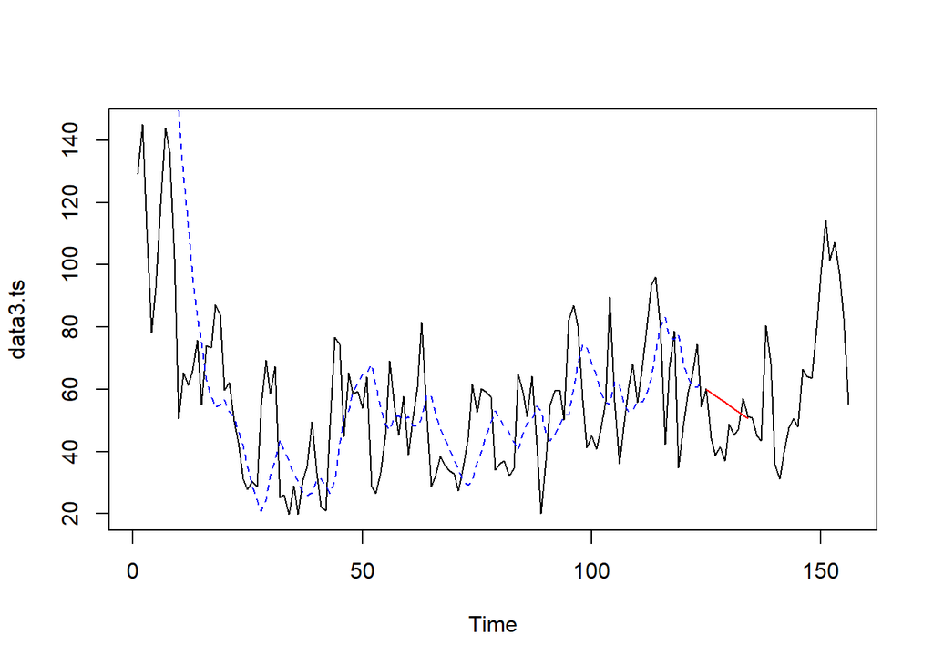

```r
plot(data3.ts)
lines(des.1$fitted[,1], lty=2, col="blue")
lines(ramalandes1$mean, col="red")
```

Untuk mendapatkan nilai parameter optimum dari DES, argumen `alpha` dan `beta` dapat dibuat `NULL` seperti berikut.

```r
#Lamda dan gamma optimum
des.opt<- HoltWinters(train.ts, gamma = FALSE)
des.opt
```

```
## Holt-Winters exponential smoothing with trend and without seasonal component.
##
## Call:
## HoltWinters(x = train.ts, gamma = FALSE)
##
## Smoothing parameters:
##  alpha: 1
##  beta : 0.06502753
##  gamma: FALSE
##
## Coefficients:
##         [,1]
## a 54.4875000
## b -0.4501149
```

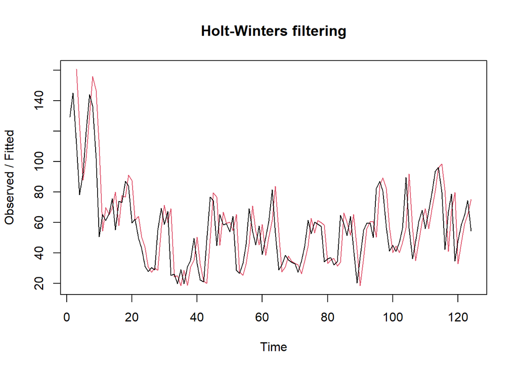

```r
plot(des.opt)
```

```r
#ramalan
ramalandesopt<- forecast(des.opt, h=10)
ramalandesopt
```

```
##     Point Forecast       Lo 80     Hi 80       Lo 95     Hi 95
## 125       54.03739  30.3611086  77.71366  17.8276449  90.24713
## 126       53.58727  18.9981534  88.17639   0.6877811 106.48676
## 127       53.13716   9.4077192  96.86659 -13.7412459 120.01556
## 128       52.68704   0.6017583 104.77232 -26.9705245 132.34461
## 129       52.23693  -7.7879601 112.26181 -39.5632151 144.03707
## 130       51.78681 -15.9430589 119.51668 -51.7970860 155.37071
## 131       51.33670 -23.9671050 126.64050 -63.8305290 166.50392
## 132       50.88658 -31.9247059 133.69787 -75.7623530 177.53551
## 133       50.43647 -39.8586970 140.73163 -87.6580689 188.53100
## 134       49.98635 -47.7987447 147.77145 -99.5630473 199.53575
```

Selanjutnya akan dilakukan perhitungan akurasi pada data latih maupun data uji dengan ukuran akurasi SSE, MSE dan MAPE.

#### Akurasi Data Latih

```r
#Akurasi Data Training
ssedes.train1<-des.1$SSE
msedes.train1<-ssedes.train1/length(train.ts)
sisaandes1<-ramalandes1$residuals
head(sisaandes1)
```

```
## Time Series:
## Start = 1
## End = 6
## Frequency = 1
## [1]        NA        NA -48.93333 -86.23100 -65.01989 -32.69188
```

```r
mapedes.train1 <- sum(abs(sisaandes1[3:length(train.ts)]/train.ts[3:length(train.ts)])
                      *100)/length(train.ts)

akurasides.1 <- matrix(c(ssedes.train1,msedes.train1,mapedes.train1))
row.names(akurasides.1)<- c("SSE", "MSE", "MAPE")
colnames(akurasides.1) <- c("Akurasi lamda=0.2 dan gamma=0.2")
akurasides.1
```

```
##      Akurasi lamda=0.2 dan gamma=0.2
## SSE                      74928.76805
## MSE                        604.26426
## MAPE                        35.12265
```

```r
ssedes.train2<-des.2$SSE
msedes.train2<-ssedes.train2/length(train.ts)
sisaandes2<-ramalandes2$residuals
head(sisaandes2)
```

```
## Time Series:
## Start = 1
## End = 6
## Frequency = 1
## [1]         NA         NA -48.933333 -59.807000  -5.791207  29.615861
```

```r
mapedes.train2 <- sum(abs(sisaandes2[3:length(train.ts)]/train.ts[3:length(train.ts)])
                      *100)/length(train.ts)

akurasides.2 <- matrix(c(ssedes.train2,msedes.train2,mapedes.train2))
row.names(akurasides.2)<- c("SSE", "MSE", "MAPE")
colnames(akurasides.2) <- c("Akurasi lamda=0.6 dan gamma=0.3")
akurasides.2
```

```
##      Akurasi lamda=0.6 dan gamma=0.3
## SSE                      52907.26801
## MSE                        426.67152
## MAPE                        32.10677
```

#### Akurasi Data Uji

```r
#Akurasi Data Testing
selisihdes1<-ramalandes1$mean-testing$PM10[1:10]
selisihdes1
```

```
## Time Series:
## Start = 125
## End = 134
## Frequency = 1
##  [1] -0.2767957 14.5094654 19.2290598 15.4069875 18.8349152  6.0295096
##  [7]  8.5616040  5.7895317 -5.4408739 -0.6254462
```

```r
SSEtestingdes1<-sum(selisihdes1^2)
MSEtestingdes1<-SSEtestingdes1/length(testing$PM10)
MAPEtestingdes1<-sum(abs(selisihdes1/testing$PM10[1:10])*100)/length(testing$PM10)

selisihdes2<-ramalandes2$mean-testing$PM10[1:10]
selisihdes2
```

```
## Time Series:
## Start = 125
## End = 134
## Frequency = 1
##  [1]  1.228007 17.252558 23.210442 20.626659 25.292877 13.725761 17.496145
##  [8] 15.962362  5.970246 12.023963
```

```r
SSEtestingdes2<-sum(selisihdes2^2)
MSEtestingdes2<-SSEtestingdes2/length(testing$PM10)
MAPEtestingdes2<-sum(abs(selisihdes2/testing$PM10[1:10])*100)/length(testing$PM10)

selisihdesopt<-ramalandesopt$mean-testing$PM10[1:10]
selisihdesopt
```

```
## Time Series:
## Start = 125
## End = 134
## Frequency = 1
##  [1] -6.229282  9.141437 14.445489 11.207874 15.220259  2.999310  6.115862
##  [8]  3.928247 -6.717701 -1.317816
```

```r
SSEtestingdesopt<-sum(selisihdesopt^2)
MSEtestingdesopt<-SSEtestingdesopt/length(testing$PM10)
MAPEtestingdesopt<-sum(abs(selisihdesopt/testing$PM10[1:10])*100)/length(testing$PM10)

akurasitestingdes <-
  matrix(c(SSEtestingdes1,MSEtestingdes1,MAPEtestingdes1,SSEtestingdes2,MSEtestingdes2,
           MAPEtestingdes2,SSEtestingdesopt,MSEtestingdesopt,MAPEtestingdesopt),
         nrow=3,ncol=3)
row.names(akurasitestingdes)<- c("SSE", "MSE", "MAPE")
colnames(akurasitestingdes) <- c("des ske1","des ske2","des opt")
akurasitestingdes
```

```
##         des ske1   des ske2    des opt
## SSE  1345.656251 2832.60020 797.009569
## MSE    42.051758   88.51876  24.906549
## MAPE    7.037136   11.04995   5.585509
```

#### Perbandingan SES dan DES

```r
MSEfull <-
  matrix(c(MSEtesting1,MSEtesting2,MSEtestingopt,MSEtestingdes1,MSEtestingdes2,
           MSEtestingdesopt),nrow=3,ncol=2)
row.names(MSEfull)<- c("ske 1", "ske 2", "ske opt")
colnames(MSEfull) <- c("ses","des")
MSEfull
```

```
##              ses      des
## ske 1   268.3475 42.05176
## ske 2   199.9514 88.51876
## ske opt 105.0676 24.90655
```

Kedua metode dapat dibandingkan dengan menggunakan ukuran akurasi yang sama. Contoh di atas adalah perbandingan kedua metode dengan ukuran akurasi MSE. Hasilnya didapatkan metode DES lebih baik dibandingkan metode SES dilihat dari MSE yang lebih kecil nilainya.

## Pemulusan Data Musiman

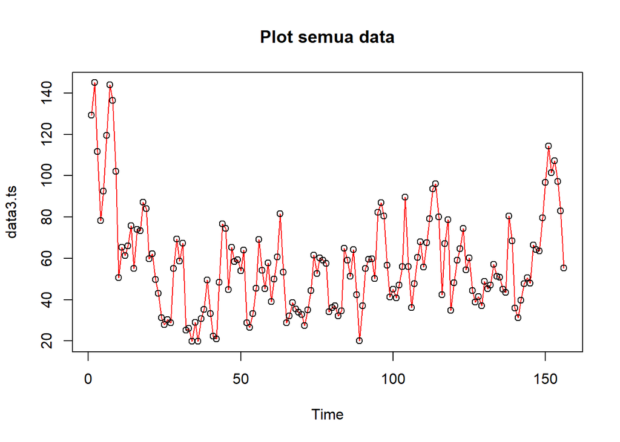

```r
#Membuat plot time series
plot(data3.ts, col="red",main="Plot semua data")
points(data3.ts)
```

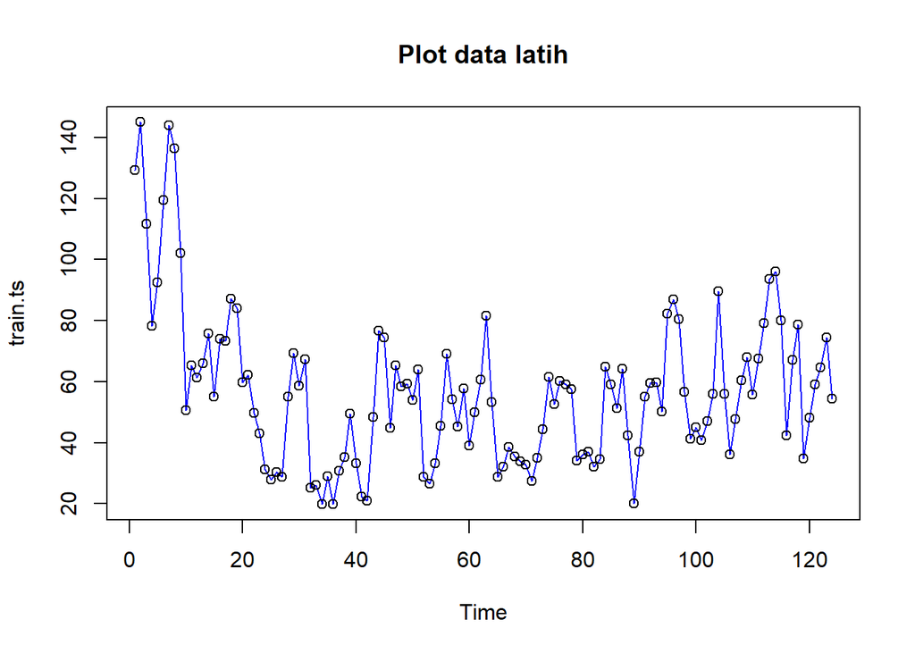

```r
plot(train.ts, col="blue",main="Plot data latih")
points(train.ts)
```

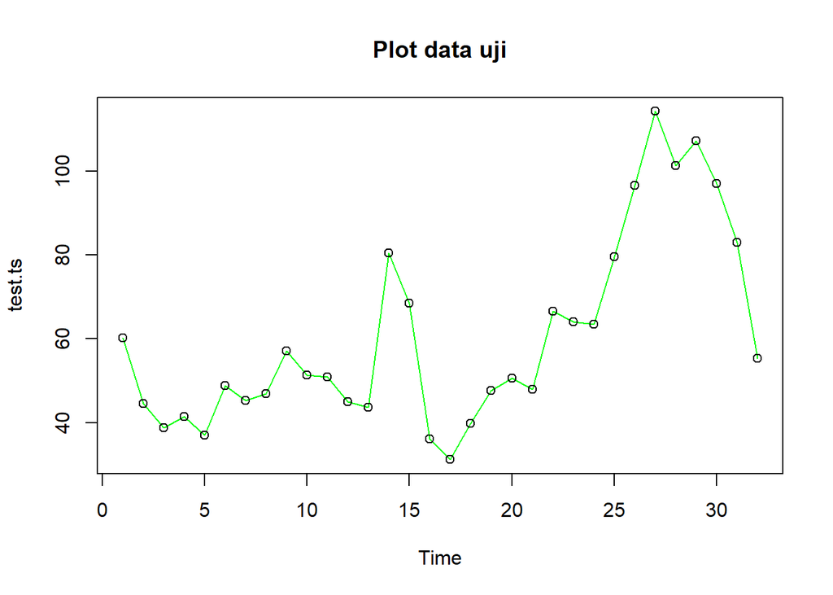

```r
plot(test.ts, col="green",main="Plot data uji")
points(test.ts)
```

Metode Holt-Winter untuk peramalan data musiman menggunakan tiga persamaan pemulusan yang terdiri atas persamaan untuk level $(L_t)$, trend $(B_t)$, dan komponen seasonal / musiman $(S_t)$ dengan parameter pemulusan berupa $\alpha$, $\beta$, dan $\gamma$. Metode Holt-Winter musiman terbagi menjadi dua, yaitu metode aditif dan metode multiplikatif.

Pemulusan data musiman dengan metode Winter dilakukan menggunakan fungsi `HoltWinters()` dengan memasukkan argumen tambahan, yaitu `gamma()` dan `seasonal()` . Arguman `seasonal()` diinisialisasi menyesuaikan jenis musiman, aditif atau multiplikatif.

### Winter Aditif

Perhitungan dengan model aditif dilakukan jika plot data asli menunjukkan fluktuasi musiman yang relatif stabil (konstan).

#### Pemulusan

```r
# Membagi data training dan testing
training <- data3[1:124, "PM10"]
testing <- data3[125:156, "PM10"]

# Mengubah menjadi data time series
train.ts <- ts(training, frequency = 7)
test.ts <- ts(testing, frequency = 7)
```

```r
#Pemulusan dengan winter aditif
winter1 <- HoltWinters(train.ts,alpha=0.2,beta=0.1,gamma=0.1,seasonal = "additive")
winter1$fitted
```

```
## Time Series:
## Start = c(2, 1)
## End = c(18, 5)
## Frequency = 7
##                   xhat     level       trend      season
##  2.000000 156.52949263 126.61898 -5.40330924  35.3138180
##  2.142857 116.93963549 117.18894 -5.80598243   5.5566752
##  2.285714  63.99106421 108.42920 -6.10135847 -38.3367772
##  2.428571  67.12992161  99.65796 -6.36834642 -26.1596939
##  2.571429  61.25280196  92.93613 -6.40369485 -25.2796344
##  2.714286  87.91231211  86.52604 -6.40433422   7.7906037
##  2.857143 110.01075731  75.73841 -6.84266380  41.1150085
##  3.000000  88.20509368  62.03110 -7.52912895  33.7031253
##  3.142857  44.07955651  47.89428 -8.18989749   4.3751710
##  3.285714  -1.31782676  45.67931 -7.59240528 -39.4047290
##  3.428571  20.59833125  53.00047 -6.10104875 -26.3010876
##  3.571429  30.14379539  60.19725 -4.77126537 -25.2821918
##  3.714286  68.53395565  66.19139 -3.69472461   6.0372854
##  3.857143  95.23862327  60.73988 -3.87040373  38.3691479
##  4.000000  76.78054229  50.25258 -4.53209286  31.0600511
##  4.142857  41.98573548  40.29522 -5.07462037   6.7651398
##  4.285714  -3.03902271  35.45178 -5.05150175 -33.4393029
##  4.428571  11.89665930  37.24558 -4.36697129 -20.9819541
##  4.571429  11.05268159  36.07595 -4.04723781 -20.9760288
##  4.714286  37.56970162  35.89567 -3.66054145   5.3345690
##  4.857143  62.38598156  30.49786 -3.83426881  35.7223914
##  5.000000  50.09159648  25.18389 -3.98223844  28.8899411
##  5.142857  28.30471338  25.04500 -3.59790371   6.8576143
##  5.285714  -6.16318930  27.52782 -2.98983131 -30.7011811
##  5.428571  18.01804191  39.24063 -1.51956752 -19.7030202
##  5.571429  18.37428202  39.17745 -1.37392836 -19.4292433
##  5.714286  42.75241448  39.33367 -1.22091400   4.6396595
##  5.857143  66.98198930  33.53061 -1.67912896  35.1305129
##  6.000000  52.25917319  24.26925 -2.43735208  30.4272800
##  6.142857  21.54709356  15.34339 -3.08620221   9.2899039
##  6.285714 -13.59883238  14.12110 -2.89981074 -24.8201259
##  6.428571  -0.05040429  20.99273 -1.92266743 -19.1204635
##  6.571429   9.24229487  28.99014 -0.93065934 -18.8171859
##  6.714286  35.20173292  32.84686 -0.45192191   2.8067997
##  6.857143  61.20683379  29.81875 -0.70953990  32.0976204
```

[output cut: 67 more lines]

```
## 16.571429  48.72160214  56.11324  0.34445988  -7.7361015
## 16.714286  62.38762751  57.87838  0.48652784   4.0227165
## 16.857143  76.55197878  59.37905  0.58794196  16.5849847
## 17.000000  73.46865831  60.47660  0.63890238  12.3531576
## 17.142857  72.91780473  65.13260  1.04061255   6.7445898
## 17.285714  67.06976778  70.82299  1.50558979  -5.2588094
## 17.428571  72.94744020  74.90379  1.76311110  -3.7194612
## 17.571429  64.51607932  70.53408  1.14982896  -7.1678296
## 17.714286  77.84799009  72.21653  1.20309071   4.4283730
## 17.857143  91.58705970  73.57919  1.21904757  16.7888264
## 18.000000  77.47679268  63.43415  0.08263971  13.9599982
## 18.142857  65.75753848  57.65644 -0.50339614   8.6044987
## 18.285714  50.94984438  55.81570 -0.63713024  -4.2287241
## 18.428571  51.40671612  57.94027 -0.36096046  -6.1725897
## 18.571429  55.31291851  62.16963  0.09807188  -6.9547826
```

```r
xhat1 <- winter1$fitted[,2]

winter1.opt<- HoltWinters(train.ts, alpha= NULL,  beta = NULL, gamma = NULL, seasonal = "additive")
winter1.opt
```

```
## Holt-Winters exponential smoothing with trend and additive seasonal component.
##
## Call:
## HoltWinters(x = train.ts, alpha = NULL, beta = NULL, gamma = NULL,     seasonal = "additive")
##
## Smoothing parameters:
##  alpha: 0.6065326
##  beta : 0.02372238
##  gamma: 0.92635
##
## Coefficients:
##          [,1]
## a  43.4385792
## b  -0.3954225
## s1 31.1999207
## s2  9.3910402
## s3 19.4633083
## s4 22.7424730
## s5 18.3687860
## s6 13.8639573
## s7 11.8308894
```

```r
winter1.opt$fitted
```

```
## Time Series:
## Start = c(2, 1)
## End = c(18, 5)
## Frequency = 7
##                 xhat      level        trend       season
##  2.000000 156.529493 126.618984 -5.403309240  35.31381803
##  2.142857 108.867629 109.003955 -5.693000320   5.55667517
##  2.285714  55.122996  99.249129 -5.789356480 -38.33677721
##  2.428571  58.728171  90.741701 -5.853835620 -26.15969388
##  2.571429  57.873789  88.911802 -5.758378268 -25.27963435
##  2.714286  87.263899  85.183515 -5.710219666   7.79060374
##  2.857143 101.672296  66.573521 -6.016233031  41.11500850
##  3.000000  66.381880  44.796663 -6.390112591  27.97532964
##  3.142857  28.168446  31.604158 -6.551481527   3.11576962
##  3.285714   6.960338  52.823207 -5.892698413 -39.97017035
##  3.428571  58.456894  87.137347 -4.938896455 -23.74155704
##  3.571429  70.977223  99.563846 -4.526947928 -24.05967500
##  3.714286  98.616592 102.917946 -4.339990704   0.03863728
##  3.857143 101.748730  75.004101 -4.899218657  31.64384766
##  4.000000  64.508082  46.089490 -5.468920948  23.88751284
##  4.142857  45.732682  31.611186 -5.682644980  19.80414071
##  4.285714   2.828733  24.357006 -5.719925532 -15.80834731
##  4.428571  17.219679  35.837596 -5.311888341 -13.30602867
##  4.571429  12.511453  36.993561 -5.158455451 -19.32365267
##  4.714286  23.648472  42.677510 -4.901247795 -14.12779078
##  4.857143  53.337532  40.951377 -4.825926530  17.21208242
##  5.000000  50.797454  37.126209 -4.802186142  18.47343059
##  5.142857  57.875375  43.551474 -4.535844258  18.85974540
##  5.285714  29.525085  39.520846 -4.523859329  -5.47190135
##  5.428571  44.540161  57.939029 -3.979619449  -9.41924871
##  5.571429  25.225133  42.289626 -4.256454521 -12.80803818
##  5.714286  22.053627  38.518317 -4.244945715 -12.21974365
##  5.857143  46.468449  32.931745 -4.276772280  17.81347671
##  6.000000  38.796090  18.102752 -4.527096080  25.22043443
##  6.142857  16.427187   2.064017 -4.800179559  19.16334901
##  6.285714   9.744281   6.021853 -4.592418593   8.31484710
##  6.428571  -3.752842  16.904537 -4.225312284 -16.43206721
##  6.571429  29.034269  45.009135 -3.458369842 -12.51649576
##  6.714286  27.640071  44.064780 -3.398731410 -13.02597793
##  6.857143  45.436736  37.439758 -3.475266710  11.47224485
```

[output cut: 67 more lines]

```
## 16.571429  64.446121  44.540434 -0.492631948  20.39831917
## 16.714286  68.062931  38.818811 -0.616676059  29.86079560
## 16.857143  47.430479  37.835427 -0.625375247  10.22042751
## 17.000000  62.578124  56.418647 -0.169701618   6.32917773
## 17.142857  91.419968  75.036925  0.275993983  16.10704955
## 17.285714  96.662004  78.191946  0.344291364  18.12576706
## 17.428571  91.857424  68.397335  0.103772464  23.35631630
## 17.571429  55.079307  38.432807 -0.609519224  17.25601920
## 17.714286  74.367252  45.162247 -0.435421647  29.64042675
## 17.857143  68.711670  47.321924 -0.373859720  21.76360531
## 18.000000  43.116632  26.359315 -0.862273894  17.61959094
## 18.142857  45.612781  28.565106 -0.789492084  17.83716682
## 18.285714  47.375423  35.938361 -0.595852281  12.03291407
## 18.428571  50.827198  45.885810 -0.345740066   5.28712763
## 18.571429  81.471585  59.812470 -0.007164748  21.66627943
```

```r
xhat1.opt <- winter1.opt$fitted[,2]
```

#### Peramalan

```r
#Forecast
forecast1 <- predict(winter1, n.ahead = 32)
forecast1.opt <- predict(winter1.opt, n.ahead = 32)
```

#### Plot Deret Waktu

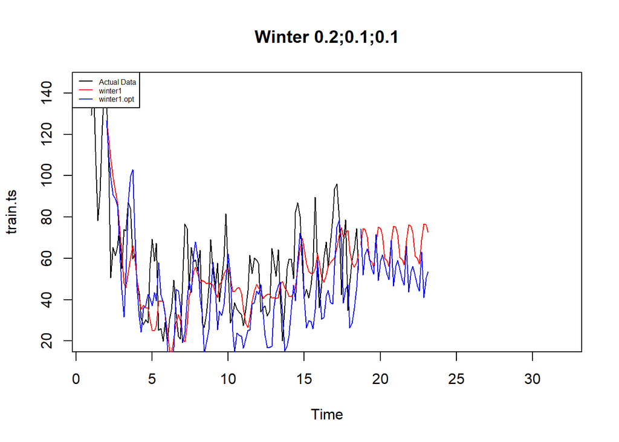

```r
#Plot time series
plot(train.ts,main="Winter 0.2;0.1;0.1",type="l",col="black",
     xlim=c(1,32),pch=12)
lines(xhat1,type="l",col="red")
lines(xhat1.opt,type="l",col="blue")
lines(forecast1,type="l",col="red")
lines(forecast1.opt,type="l",col="blue")
legend("topleft",c("Actual Data",expression(paste(winter1)),
                   expression(paste(winter1.opt))),cex=0.5,
       col=c("black","red","blue"),lty=1)
```

#### Akurasi Data Latih

```r
#Akurasi data training
SSE1<-winter1$SSE
MSE1<-winter1$SSE/length(train.ts)
RMSE1<-sqrt(MSE1)
akurasi1 <- matrix(c(SSE1,MSE1,RMSE1))
row.names(akurasi1)<- c("SSE", "MSE", "RMSE")
colnames(akurasi1) <- c("Akurasi")
akurasi1
```

```
##          Akurasi
## SSE  80669.02168
## MSE    650.55663
## RMSE    25.50601
```

```r
SSE1.opt<-winter1.opt$SSE
MSE1.opt<-winter1.opt$SSE/length(train.ts)
RMSE1.opt<-sqrt(MSE1.opt)
akurasi1.opt <- matrix(c(SSE1.opt,MSE1.opt,RMSE1.opt))
row.names(akurasi1.opt)<- c("SSE1.opt", "MSE1.opt", "RMSE1.opt")
colnames(akurasi1.opt) <- c("Akurasi")
akurasi1.opt
```

```
##               Akurasi
## SSE1.opt  54515.51099
## MSE1.opt    439.64122
## RMSE1.opt    20.96762
```

```r
akurasi1.train = data.frame(Model_Winter = c("Winter 1","Winter1 optimal"),
                            Nilai_SSE=c(SSE1,SSE1.opt),
                            Nilai_MSE=c(MSE1,MSE1.opt),Nilai_RMSE=c(RMSE1,RMSE1.opt))
akurasi1.train
```

```
##      Model_Winter Nilai_SSE Nilai_MSE Nilai_RMSE
## 1        Winter 1  80669.02  650.5566   25.50601
## 2 Winter1 optimal  54515.51  439.6412   20.96762
```

#### Akurasi Data Uji

```r
#Akurasi Data Testing
selisih1<-forecast1-test.ts
SSEtesting1<-sum(selisih1^2)
MSEtesting1<-SSEtesting1/length(test.ts)

selisih1.opt<-forecast1.opt-test.ts
SSEtesting1.opt<-sum(selisih1.opt^2)
MSEtesting1.opt<-SSEtesting1.opt/length(test.ts)
```

```r
akurasi_testing <- data.frame(
  Model = c("Model1", "Model Optimum"),
  SSE   = c(SSEtesting1, SSEtesting1.opt),
  MSE   = c(MSEtesting1, MSEtesting1.opt)
)

akurasi_testing
```

```
##           Model SSE MSE
## 1        Model1   0   0
## 2 Model Optimum   0   0
```

### Winter Multiplikatif

Model multiplikatif digunakan cocok digunakan jika plot data asli menunjukkan fluktuasi musiman yang bervariasi.

#### Pemulusan

```r
#Pemulusan dengan winter multiplikatif
winter2 <- HoltWinters(train.ts,alpha=0.2,beta=0.1,gamma=0.3,seasonal = "multiplicative")
winter2$fitted
```

```
## Time Series:
## Start = c(2, 1)
## End = c(18, 5)
## Frequency = 7
##                xhat     level        trend    season
##  2.000000 164.06422 126.61898 -5.403309240 1.3534901
##  2.142857 118.05480 117.12722 -5.812154247 1.0605465
##  2.285714  58.31599 108.31964 -6.111697374 0.5705622
##  2.428571  69.83969  99.51785 -6.380706580 0.7498587
##  2.571429  67.34877  91.94300 -6.500120928 0.7882315
##  2.714286  82.90719  83.88802 -6.655606689 1.0734766
##  2.857143  94.21269  74.08165 -6.970683028 1.4038344
##  3.000000  74.22489  64.47174 -7.234605700 1.2967961
##  3.142857  47.95506  54.29786 -7.528533596 1.0253529
##  3.285714  24.74263  51.84057 -7.021408578 0.5520546
##  3.428571  42.17064  62.39256 -5.264068936 0.7381718
##  3.571429  50.28905  69.29825 -4.047093183 0.7706998
##  3.714286  72.14225  73.99173 -3.173036060 1.0186894
##  3.857143  86.72589  68.38571 -3.416333954 1.3348733
##  4.000000  69.72617  61.28787 -3.784484566 1.2125575
##  4.142857  57.37428  54.19270 -4.115553375 1.1457178
##  4.285714  31.93057  47.59266 -4.364002191 0.7386437
##  4.428571  34.53678  43.02746 -4.384122143 0.8937319
##  4.571429  28.70521  37.15442 -4.533013521 0.8799502
##  4.714286  27.80193  33.00377 -4.494777580 0.9751987
##  4.857143  30.04743  28.73077 -4.472599460 1.2386517
##  5.000000  27.20984  28.28514 -4.069902341 1.1236658
##  5.142857  30.48685  31.70830 -3.320596026 1.0739457
##  5.285714  22.65807  33.64337 -2.795029797 0.7344989
##  5.428571  35.25491  43.01770 -1.578093324 0.8507538
##  5.571429  33.26706  39.09936 -1.812118875 0.8921836
##  5.714286  33.15812  35.66379 -1.974463510 0.9842321
##  5.857143  41.67827  30.98337 -2.245059246 1.4502688
##  6.000000  35.45304  26.99967 -2.418922743 1.4423092
##  6.142857  25.22067  22.41251 -2.635746954 1.2752678
##  6.285714  17.82228  20.66222 -2.547200884 0.9838396
##  6.428571  15.37190  21.65951 -2.192751711 0.7896485
##  6.571429  22.60120  28.12330 -1.327098217 0.8434481
##  6.714286  24.87135  29.30447 -1.076271527 0.8810817
##  6.857143  35.48251  27.64924 -1.134166553 1.3382013
```

[output cut: 67 more lines]

```
## 16.571429  55.67102  51.08980  0.179192956 1.0858614
## 16.714286  65.52053  51.29735  0.182029126 1.2727529
## 16.857143  63.03277  51.78389  0.212479658 1.2122534
## 17.000000  56.73605  54.64717  0.477559999 1.0292305
## 17.142857  67.92180  62.27922  1.193009298 1.0701026
## 17.285714  79.60215  68.75114  1.720900104 1.1295565
## 17.428571  88.06649  70.53289  1.726985384 1.2187468
## 17.571429  71.41276  64.74672  0.975670015 1.0865818
## 17.714286  84.39050  64.94314  0.897745082 1.2817340
## 17.857143  84.34860  64.94450  0.808106028 1.2828176
## 18.000000  67.99195  58.02244  0.035089914 1.1711133
## 18.142857  63.54217  54.67324 -0.303339326 1.1687012
## 18.285714  60.18273  53.60472 -0.379857404 1.1307259
## 18.428571  56.37044  54.03418 -0.298925343 1.0490400
## 18.571429  61.26685  57.16466  0.044014834 1.0709364
```

```r
xhat2 <- winter2$fitted[,2]

winter2.opt<- HoltWinters(train.ts, alpha= NULL,  beta = NULL, gamma = NULL, seasonal = "multiplicative")
winter2.opt$fitted
```

```
## Time Series:
## Start = c(2, 1)
## End = c(18, 5)
## Frequency = 7
##                xhat     level     trend    season
##  2.000000 164.06422 126.61898 -5.403309 1.3534901
##  2.142857 106.47055 105.96211 -5.569948 1.0605465
##  2.285714  52.35706  97.36697 -5.602997 0.5705622
##  2.428571  62.90796  89.52059 -5.627505 0.7498587
##  2.571429  63.63769  86.33558 -5.600822 0.7882315
##  2.714286  78.17167  78.44685 -5.625816 1.0734766
##  2.857143  82.31984  64.35755 -5.718276 1.4038344
##  3.000000  64.44800  55.11400 -5.756788 1.3057464
##  3.142857  40.24505  44.05332 -5.814731 1.0524720
##  3.285714  32.08640  62.13758 -5.553645 0.5670586
##  3.428571  79.87611 110.75009 -4.961902 0.7550570
##  3.571429  84.54467 112.91478 -4.884047 0.7825983
##  3.714286 106.58283 107.48360 -4.890025 1.0388840
##  3.857143  88.02043  68.95590 -5.257502 1.3818311
##  4.000000  56.16428  49.73081 -5.410092 1.2672239
##  4.142857  40.34901  40.48738 -5.451970 1.1516638
##  4.285714  19.94758  36.84481 -5.432203 0.6350183
##  4.428571  30.15732  44.62007 -5.287917 0.7667345
##  4.571429  24.86109  37.11913 -5.312093 0.7816221
##  4.714286  29.11347  37.08285 -5.254457 0.9147012
##  4.857143  33.94925  31.64066 -5.256508 1.2867289
##  5.000000  41.41891  38.58430 -5.123226 1.2378236
##  5.142857  52.83742  50.27323 -4.939561 1.1655226
##  5.285714  30.09939  49.09229 -4.898499 0.6810775
##  5.428571  60.85996  85.00500 -4.452654 0.7555331
##  5.571429  32.83722  45.43267 -4.836322 0.8088713
##  5.714286  26.85964  34.31212 -4.904974 0.9133713
##  5.857143  25.93476  23.67381 -4.967609 1.3864258
##  6.000000  20.68468  20.39405 -4.949170 1.3392581
##  6.142857  11.88197  14.96126 -4.954453 1.1873889
##  6.285714  13.02650  21.93716 -4.824119 0.7612031
##  6.428571  21.01831  38.90606 -4.586039 0.6124212
##  6.571429  50.12199  69.08324 -4.206266 0.7725698
##  6.714286  37.91326  48.51292 -4.385036 0.8591679
##  6.857143  36.85315  30.58602 -4.532975 1.4145425
```

[output cut: 67 more lines]

```
## 16.571429  48.45933  57.57383 -1.960468 0.8713613
## 16.714286  59.57001  61.92085 -1.891561 0.9923490
## 16.857143  61.43436  65.96077 -1.826762 0.9579062
## 17.000000  72.56711  77.89497 -1.676430 0.9520926
## 17.142857 106.69872  92.66661 -1.496741 1.1703288
## 17.285714 102.10677  84.45484 -1.570100 1.2319128
## 17.428571  78.65309  69.46170 -1.716741 1.1610176
## 17.571429  37.86636  44.37036 -1.972099 0.8931113
## 17.714286  66.11066  66.88858 -1.704552 1.0142157
## 17.857143  72.75697  74.40640 -1.603802 0.9993732
## 18.000000  42.24733  44.43728 -1.913681 0.9935031
## 18.142857  51.76560  46.97562 -1.865045 1.1475268
## 18.285714  56.38768  49.86080 -1.813150 1.1735783
## 18.428571  52.18993  53.36984 -1.755008 1.0111423
## 18.571429  64.62103  67.97413 -1.576289 0.9732400
```

```r
xhat2.opt <- winter2.opt$fitted[,2]
```

#### Peramalan

```r
#Forecast
forecast2 <- predict(winter2, n.ahead = 32)
forecast2.opt <- predict(winter2.opt, n.ahead = 32)
```

#### Plot Deret Waktu

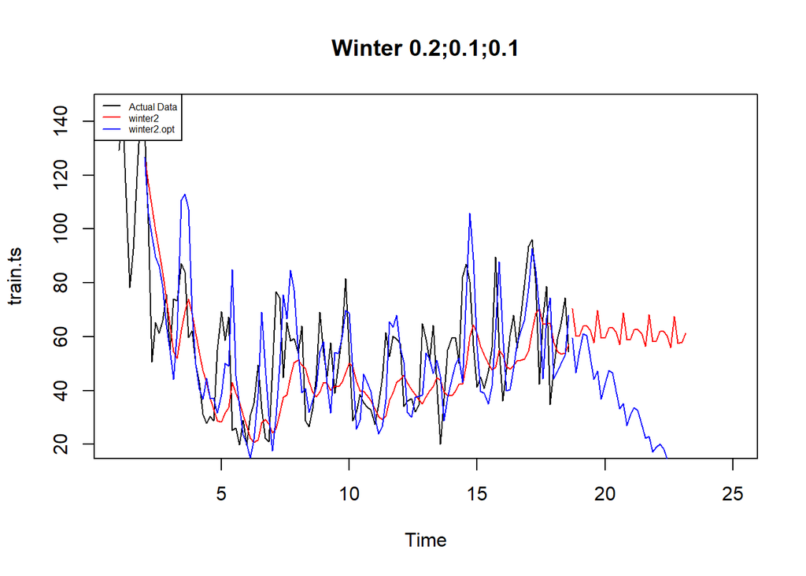

```r
#Plot time series
plot(train.ts,main="Winter 0.2;0.1;0.1",type="l",col="black",
     xlim=c(1,25),pch=12)
lines(xhat2,type="l",col="red")
lines(xhat2.opt,type="l",col="blue")
lines(forecast2,type="l",col="red")
lines(forecast2.opt,type="l",col="blue")
legend("topleft",c("Actual Data",expression(paste(winter2)),
                   expression(paste(winter2.opt))),cex=0.5,
       col=c("black","red","blue"),lty=1)
```

#### Akurasi Data Latih

```r
#Akurasi data training
SSE2<-winter2$SSE
MSE2<-winter2$SSE/length(train.ts)
RMSE2<-sqrt(MSE2)
akurasi1 <- matrix(c(SSE2,MSE2,RMSE2))
row.names(akurasi1)<- c("SSE2", "MSE2", "RMSE2")
colnames(akurasi1) <- c("Akurasi lamda=0.2")
akurasi1
```

```
##       Akurasi lamda=0.2
## SSE2        53935.46048
## MSE2          434.96339
## RMSE2          20.85578
```

```r
SSE2.opt<-winter2.opt$SSE
MSE2.opt<-winter2.opt$SSE/length(train.ts)
RMSE2.opt<-sqrt(MSE2.opt)
akurasi1.opt <- matrix(c(SSE2.opt,MSE2.opt,RMSE2.opt))
row.names(akurasi1.opt)<- c("SSE2.opt", "MSE2.opt", "RMSE2.opt")
colnames(akurasi1.opt) <- c("Akurasi")
akurasi1.opt
```

```
##               Akurasi
## SSE2.opt  46961.16750
## MSE2.opt    378.71909
## RMSE2.opt    19.46071
```

```r
akurasi2.train = data.frame(Model_Winter = c("Winter 1","winter2 optimal"),
                            Nilai_SSE=c(SSE2,SSE2.opt),
                            Nilai_MSE=c(MSE2,MSE2.opt),Nilai_RMSE=c(RMSE2,RMSE2.opt))
akurasi2.train
```

```
##      Model_Winter Nilai_SSE Nilai_MSE Nilai_RMSE
## 1        Winter 1  53935.46  434.9634   20.85578
## 2 winter2 optimal  46961.17  378.7191   19.46071
```

#### Akurasi Data Uji

```r
#Akurasi Data Testing
forecast2<-data.frame(forecast2)
test.ts<-data.frame(test.ts)
selisih2<-forecast2-test.ts
SSEtesting2<-sum(selisih2^2)
MSEtesting2<-SSEtesting2/length(test.ts)

forecast2.opt<-data.frame(forecast2.opt)
selisih2.opt<-forecast2.opt-test.ts
SSEtesting2.opt<-sum(selisih2.opt^2)
MSEtesting2.opt<-SSEtesting2.opt/length(test.ts)
```

```r
# Atau rapikan dalam tabel
akurasi_testing2 <- data.frame(
  Model = c("Model2", "Model2 Optimal"),
  SSE   = c(SSEtesting2, SSEtesting2.opt),
  MSE   = c(MSEtesting2, MSEtesting2.opt)
)

akurasi_testing2
```

```
##            Model      SSE      MSE
## 1         Model2 16940.65 16940.65
## 2 Model2 Optimal 65787.15 65787.15
```

## Kesimpulan

Berdasarkan seluruh metode pemulusan yang diterapkan pada data PM10, yaitu Single Moving Average (SMA), Double Moving Average (DMA), Single Exponential Smoothing (SES), Double Exponential Smoothing (DES), serta Winter Aditif dan Winter Multiplikatif, diperoleh tingkat akurasi yang berbeda-beda pada data uji. Metode SMA dengan m = 4 menghasilkan nilai MAPE sebesar 34,20%, sedangkan DMA menunjukkan performa yang lebih rendah dengan MAPE sebesar 122,39%. Hal tersebut menunjukkan bahwa metode DMA kurang sesuai untuk karakteristik data PM10 yang cenderung fluktuatif. Pada metode pemulusan eksponensial, SES dengan parameter optimum menghasilkan MAPE sebesar 21,07% dan RMSE sebesar 10,25. Sementara itu, performa terbaik diperoleh dari DES dengan parameter optimum, yang menghasilkan MAPE sebesar 5,59% pada data uji.

Hasil tersebut menunjukkan bahwa DES lebih mampu mengikuti pola data PM10 dibandingkan metode lainnya, khususnya karena metode ini mempertimbangkan komponen level dan tren dalam proses peramalan. Pada Winter Multiplikatif, model dengan parameter awal menghasilkan SSE data uji sebesar 16.940,65, sedangkan model dengan parameter optimum menghasilkan SSE yang lebih besar, yaitu 65.787,15. Kondisi tersebut menunjukkan bahwa optimasi parameter pada model tersebut belum tentu menghasilkan performa terbaik pada data uji dan dapat mengindikasikan adanya overfitting terhadap data latih. Sementara itu, evaluasi akurasi Winter Aditif masih memerlukan perbaikan karena terdapat kendala dalam penyelarasan indeks waktu antara hasil peramalan dan data uji.

Secara keseluruhan, berdasarkan hasil evaluasi seluruh metode yang digunakan, Double Exponential Smoothing (DES) dengan parameter optimum dapat direkomendasikan sebagai metode terbaik untuk peramalan data PM10 pada praktikum ini. Metode tersebut menghasilkan nilai kesalahan peramalan paling kecil pada data uji, sehingga dinilai paling mampu memberikan hasil peramalan yang sesuai dengan karakteristik data PM10 dibandingkan metode lainnya.